# EDA Project

The EDA project in this course has four main parts to it:

1. Project Proposal
2. Phase 1
3. Phase 2
4. Report

This notebook will be used for Project Proposal, Phase 1, and Phase 2. You will have specific questions to answer within this notebook for Project Proposal and Phase 1. You will also continue using this notebook for Phase 2. However, guidance and expectations can be found on Canvas for that assignment. The report is completed outside of this notebook and details can be found on the EDA Report page on Canvas.

**Read this before proceeding:**

1. Review the list of data sets and sources of data to avoid before choosing your data. This list is provided in the instructions for the Project Proposal assignment in Canvas.
2. It is expected that when you are asked questions requiring typed explanations you are to use a **markdown cell** to type your answers neatly. *Do not provide typed answers to questions as extra comments within your code or within a code cell.* Only provide comments within your code as you normally would, i.e. as needed to explain or remind yourself what each part of the code is doing.

# Project Proposal

The intent of this proposal is for you to share your chosen data file(s) with your instructor and provide general information on your goals for the EDA project.

**Step 1 (2 pts)**: Give a brief *description* of the source(s) of your data and include a *direct link* to your data.

Sources: (1) DEMO_L.xpt https://wwwn.cdc.gov/nchs/nhanes/search/datapage.aspx?Component=Demographics&Cycle=2021-2023

(2) DR1TOT_L.xpt https://wwwn.cdc.gov/nchs/nhanes/search/datapage.aspx?Component=Dietary&Cycle=2021-2023

(3) GLU_L.xpt https://wwwn.cdc.gov/nchs/nhanes/search/datapage.aspx?Component=Laboratory&Cycle=2021-2023

(4) BMX_L.xpt https://wwwn.cdc.gov/nchs/nhanes/search/datapage.aspx?Component=Examination&Cycle=2021-2023

(5) DIQ_L.xpt https://wwwn.cdc.gov/nchs/nhanes/search/datapage.aspx?Component=Questionnaire&Cycle=2021-2023

Each file has a corresponding codebook at the provided link, with information about each variable in the dataset. Many variables follow a numeric code system, with a specific number corresponding to specific health criteria. These variables will be cleaned and updated in the EDA. Column names will also be updated during the data cleaning process according to these codebooks.

**Step 2 (4 pts)**: Briefly explain why you chose this data. What about the data interests you? Which specific fields will be the focus of your analysis (list at least 3)?

Maintaining metabolic health is imperative to preventing the development of chronic health conditions like diabetes, heart disease, and more. In screening for metabolic health, patients with a higher Body Mass Index (BMI) are often labeled at risk for developing these conditions. However, BMI is highly criticized as a metric of overall patient health, failing to take into account muscle mass, body fat distribution, gender, genetics and diet. This could bias assessments of health to underdiagnose "lean" individuals, delaying critical testing and care. Understanding how to better diagnose these populations is critical, especially with the rise in prevalence of diabetes among patients with lower BMI (7).

Existing standards for determining overall health like BMI fail to capture the entire picture of how diet, exercise, genetics, and social determinants of health contribute to patient risk and overall outcomes. This analysis will focus on how measures of dietary fitness (dietary fiber, protein, carbohydrate, total sugar, and fat intake), demographic information (gender, poverty level, racial/ethnic background) and detailed medical assessment tools provide a clearer assessment of diabetes and prediabetes risk than BMI alone. Fasting glucose and diabetes diagnosis status will be key outcome indicator of subject metabolic health. The goal is to develop a better standard of risk assessment and increase patient awareness of diabetes risk at any BMI, incorporating all aspects contributing to patient health.

In the datasets provided, these variables correspond to the following fields:

Diabetes Diagnosis status

- Diabetes diagnosis: DIQ010 in DIQ_L (diabetes) dataset

Medical Assessment Tools

- BMI: BMXBMI in BMX_L (bmi) dataset
- Waist circumference: BMXWAIST in BMX_L (bmi) dataset

Metabolic Health Indicators

- Fasting glucose: LBXGLU in GLU_L (glucose) dataset

Nutrition

- Fiber: DR1TFIBE in DR1TOT_L (nutrients) dataset
- Protein: DR1TPROT in DR1TOT_L (nutrients) dataset
- Total sugars: DR1TSUGR in DR1TOT_L (nutrients) dataset
- Carbohydrates: DR1TCARB in DR1TOT_L (nutrients) dataset

Social determinants

Patient identifier number

- SEQN in all datasets (will be used to merge pull relevant information from all datasets provided)

(7) Adesoba, T. P., & Brown, C. C. (2023). Trends in the Prevalence of Lean Diabetes Among U.S. Adults, 2015-2020. Diabetes care, 46(4), 885–889. https://doi.org/10.2337/dc22-1847

**Step 3 (2 pts)**: Provide a brief overview of your goals as it relates to your analysis plans.

Aim 1: Examining BMI, metabolic health indicators and diabetes prevalence

This analysis will evaluate how BMI correlates with fasting glucose, insulin levels, and diabetes diagnosis status. I am particularly interested in how lean BMI places patients at risk for underdiagnosis, despite laboratory results indicating diabetes or prediabetes.

Aim 2: Assess BMI as a risk assessment tool across subpopulations

This analysis will examine how BMI potentially underdiagnoses specific patient subpopulations by failing to account for differences in risk due to gender, socioeconomic status, and racial/ethnic background. This analysis will provide clear indications of how BMI fails to clearly detail diabetes risk across all patient populations.

Aim 3: Compare how BMI and other medical assessment tools determine diabetes risk across patient subpopulations

This analysis will determine how diet (specifically daily macronutrients), medical assessments (like waist circumference, which is known to be a better assessment of weight distribution than BMI), interact with fasting glucose and diabetes diagnosis status. Expanding upon these analyses, demographic factors like gender, socioeconomic status, and racial/ethnic background will be considered, determining if these alternative diabetes risk assessment approaches provide a clearer picture of patient metabolic health across all subpopulations.

Overall, this analysis will clarify how BMI provides an incomplete picture of a patient's overall metabolic health. Further, it will demonstrate that diabetes risk assessment must include measures of diet health, more accurate metrics of weight distribution, and social determinants of health to fully determine patient risk.

**Step 4 (1 pt)**: Read the data into this notebook. If you have more than one file, you need to repeat this step for each file. Use a different cell for each file.

```python
# Set up notebook to display multiple outputs in one cell
from IPython.core.interactiveshell import InteractiveShell
InteractiveShell.ast_node_interactivity = "all"

# Import necessary libraries
import pandas as pd
import numpy as np

import seaborn as sns
import matplotlib.pyplot as plt
import plotly.express as px

%matplotlib inline

# read in demographics data
demographics = pd.read_sas('data/DEMO_L.xpt', format = 'xport')
```

```python
# read in glucose data
glucose = pd.read_sas('data/GLU_L.xpt', format = 'xport')
```

```python
# read in bmi data
bmi = pd.read_sas('data/BMX_L.xpt', format = 'xport')
```

```python
# read in nutrients data
nutrients = pd.read_sas('data/DR1TOT_L.xpt', format = 'xport')
```

```python
# read in diabetes data
diabetes = pd.read_sas('data/DIQ_L.xpt', format = 'xport')
```

**Step 5 (3 pts)**: Inspect the data using the **info( )**, **head( )**, and **tail( )** methods. Make sure your header is showing accurately as you learned in the Module 4 python homework. Repeat for as many files as you have and use a new cell for each file.

```python
# TODO: Use the info() method to determine to inspect the variable (column) names, the number of non-null values,
#       and the data types for each variable.
demographics.info()
```

```python
# TODO: Use the head() method to inspect the first five (or more) rows of the data
demographics.head(5)
```

```python
# TODO: Use the tail() method to inspect the last five (or more) rows of the data
demographics.tail(5)
```

```python
# inspecting glucose
glucose.info()
```

```python
# head of glucose
glucose.head(5)
```

```python
# tail of glucose
glucose.tail(5)
```

```python
# inspecting bmi
bmi.info()
```

```python
# head of bmi
bmi.head(5)
```

```python
# tail of bmi
bmi.tail(5)
```

```python
# inspecting nutrients
nutrients.info()
```

```python
# head of nutrients
nutrients.head(5)
```

```python
# tail of nutrients
nutrients.tail(5)
```

```python
# inspecting diabetes
diabetes.info()
```

```python
# head of diabetes
diabetes.head(5)
```

```python
# tail of diabetes
diabetes.tail(5)
```

**Step 6 - Files uploaded (3 pts)**:

- All data files were uploaded into Canvas
- HTML and .ipynb were uploaded into Canvas
- HTML and .ipynb have student's last name in file title (example: Smith_EDA_Project)

**STOP HERE for your Project Proposal assignment. Submit your (1) original data file(s) along with (2) the completed notebook up to this point, and (3) the html file for grading and approval.**

**Instructor Feedback and Approval (3 pts)**: Your instructor will provide feedback in either the cell below this or via Canvas. You can expect one of the following point values for this portion.

**3 pts** - if your project goals and data set are both approved.  
**2 pts** - if your data set is approved but changes to your project goals (Step 3) are needed.  
**1 pt** - if your project goals are approved but your data set is not approved.  
**0 pts** - if neither your data set nor your project goals are approved.

*As needed, follow your instructor's feeback and guidance to get on track for the remaining portions of the EDA project.*

# EDA Phase 1 - Inspect, Clean and Prep Data

The overall goal of this assignment is to take all necessary steps to inspect the quality of your data and prepare the data according to your needs. For information and resources on the process of Exploratory Data Analysis (EDA), you should explore the **EDA Project Resources Module** in Canvas.

Once you’ve read through the information provided in that module and have a comfortable understanding of EDA using Python, complete steps 7 through 11 listed below to satisfy the requirements for your EDA Phase 1 assignment. **Remember to convert code cells provided to markdown cells for any typed responses to questions.**

**Step 7 (2 pts)**: Begin by elaborating in more detail from the previous assignment on why you chose this data?

1. Explain what you hope to learn from this data.
2. Do you have a hunch about what this data will reveal? (The answer to this question will be used in the Introduction section of your EDA report.)

In exploring this data, I aim to determine the relationship between metabolic health indicators, BMI, and demographic factors. In particular, I hope to learn about how BMI correlates (or does not correlate) with diabetes diagnosis, fasting glucose levels, particularly in how it could underpredict diabetes risk for lean BMI individuals. Further, BMI's efficacy as a diabetes risk assessment tool across different gender, racial/ethnic and socioeconomic backgrounds will be explored. Finally, I would like to determine if there are other medical assessment approaches like measures of daily macronutrients and fat distribution might better capture diabetes risk.

BMI has been criticized for years about its inaccuracy in determining patient health and risk for developing metabolic disorders like diabetes. In particular, it fails to capture variations in body type across gender and race/ethnicity and fails to account for social determinants of health, like socioeconomic status, that place patients at greater risk for developing diabetes. I predict that BMI will not be the best risk assessment tool for determining diabetes risk, especially when examining social and demographic risk factors.

**Step 8 (2 pts)**: Discuss the popluation and the sample:

1. What is the population being represented by the data you’ve chosen?
2. What is the total sample size? Does it represent the entire population or is it a subset of data?
3. Explain anything particular about your data - example: was it a random sample or were sampling weights used with your data?

The population being represented by this data is a sample of United States residents from the August 2021 - August 2023 who completed the NHANES, administered by the Center for Disease Control.

The total sample size in this instance varies based on the specific survey portion or outcome metric selected. The demographics dataset includes the total sample size of 11933 participants. This sample includes all patients who underwent the demographics survey. However, some of these participants did not undergo physical examinations, laboratory testing, or dietary questionnaires.

- Demographics: n = 11933, representing the entire population of NHANES participants
- BMI: n = 8860, representing the subset of the NHANES participants that underwent the physical exam
- Nutrients: n = 8860, representing the subset of the NHANES participants that underwent the dietary questionnaire day 1
- Glucose: n = 3996, representing the subset of the NHANES participants that underwent laboratory testing
- Diabetes: n = 11744, representing the subset of the NHANES participants that underwent the diabetes questionnaire

These datasets all contain anonymized patient identifier numbers that will make consolidating data across datasets feasible. Some analyses will be restricted to patients that meet the response/sample criteria. For example, analysis on a patient's glucose cannot be completed if they did not receive laboratory testing.

The NHANES oversamples populations that might have different or unique health outcomes relative to the general population. This is done to better assess the health and needs of these populations. NHANES oversamples the following groups: children and adolescents, 60+ year old adults, and people of Asian, African American, and/or Hispanic backgrounds (8).

(8) https://www.cdc.gov/nchs/nhanes/about/who-participates.html

**Step 9 (4 pts)**: In the Project Proposal assignment you used the info( ) method to inspect the variables, their data types, and the number of non-null values. Using that information as a guide, provide definitions of each of your variables and their corresponding data types, i.e. a data dictionary.

- Use an HTML table which is demonstrated below.
- No need to include the variables that you will end up dropping and not use in your analysis.

[output not shown]

**Step 10 (4 pts)**:

### Inspect your data

Before you can clean/prep your data, you have to know what each field contains. Even if you think the field contains clean data, you need to inspect it to make sure.

- All numerical fields must be inspected (use describe and/or boxplots - more involved displays will be part of Phase 2)
  - Are there outliers? What does the outlier(s) represent? Valid data or dirty data?
- All string objects must be inspected (value_counts)
- Are there missing values in columns you plan to use?

  **You must use `markdown` cells and explain what you are seeing in each step. Remember, this is the inspection part of Phase 1.**

Include your work below and add as many cells as you need.

## INSPECTING DEMOGRAPHICS

In the case of the NHANES data, some categorical variables are recorded in a numeric form to consolidate the data collection process. For example, in the case of RIAGENDR (the participant's gender), the float 1.0 corresponds to "Male" and 2.0 corresponds to "Female". These values are reported in the data colleciton information on the NHANES website. These variables need to be cleaned and their data type needs to change, as they are not truly representing numeric data. In the intial inspection, these data types will be changed to strings. However, cleaning their values to represent what each number code reflects will be completed during cleaning phases.

### CATEGORICAL DEMOGRAPHIC VARIABLES

#### Initial Processing

```python
# some initial cleaning
print(demographics['SEQN'].dtype,
demographics['RIAGENDR'].dtype,
demographics['RIDRETH3'].dtype,)

# converting number code to codebook value
demographics['RIAGENDR'] = demographics['RIAGENDR'].replace({1.0: 'male', 2.0: 'female'})
demographics['RIDRETH3'] = demographics['RIDRETH3'].replace({1.0 : 'Mexican American',
                                                             2.0 : 'Other Hispanic',
                                                             3.0 : 'Non-Hispanic White',
                                                             4.0 : 'Non-Hispanic Black',
                                                             6.0 : 'Non-Hispanic Asian',
                                                             7.0 : 'Other Race - Including Multi-Racial'})

# seqn is a unique value for each participant,
demographics['SEQN'] = demographics['SEQN'].astype(str)
```

#### Inspection

```python
## value counts
'''SEQN'''
print(demographics['SEQN'].value_counts())
'''RIAGENDR'''
print(demographics['RIAGENDR'].value_counts())
'''RIDRETH3'''
print(demographics['RIDRETH3'].value_counts())
```

These results show the relative distribution of each variable value for each column in the dataset. Note, the variable SEQN is an anonymized, unique respondent tracking number. This variable will be inspected across all datasets, to ensure appropriate allocation of each identifier number to each respondent. Analysis will not be performed on these values, they will simply be used to merge and track informatin across datasets.

```python
## missingness check
print('SEQN')
print(demographics['SEQN'].isna().sum())
print('RIAGENDR')
print(demographics['RIAGENDR'].isna().sum())
print('RIDRETH3')
print(demographics['RIDRETH3'].isna().sum())
```

There are no missing values in columns representing patient SEQN, gender and race/ethnicity

### NUMERIC DEMOGRAPHIC VARIABLES

```python
print('RIDAGEYR')
print(demographics['RIDAGEYR'].describe())
print('INDFMPIR')
print(demographics['INDFMPIR'].describe())
```

```python
demographics.boxplot(column = ['RIDAGEYR'])
plt.show()
```

[output not shown]

There are no outliers in age of respondent. The median age of respondents is approximately 37 years old. The range of respondents is from 0 to 80 years old.

```python
demographics.boxplot(column = ['INDFMPIR'])
plt.show()
```

[output not shown]

There are no outliers in the family income to poverty ratio column. The median family income to poverty ratio is 2.5. The range of family income to poverty ratio extends from 0 to 5. Note, in cases where the income to poverty ratio is 0, this could potentially mean the household is experiencing unemployment or is currently attending school.

```python
## missingness check
print('RIDAGEYR')
print(demographics['RIDAGEYR'].isna().sum())

print('INDFMPIR')
print(demographics['INDFMPIR'].isna().sum())
```

Age is not missing any values. Family income to poverty ratio is missing values. This can be remedied later with filling Na values, depending on the context

## INSPECTING NUTRIENTS

Again, the categorical variables in this dataset are coded in with number codes, rather than their true values. This will be adjusted prior to inspection

### CATEGORICAL NUTRIENT VARIABLES

#### Initial Processing

```python
print(nutrients['SEQN'].dtype)
print(nutrients['DR1DRSTZ'].dtype)

# converting number to codebook value
nutrients['DR1DRSTZ'] = nutrients['DR1DRSTZ'].replace({1.0: 'Reliable and met the minimum criteria',
                                                             2.0: 'Not reliable or not met the minimum criteria',
                                                             4.0: 'Reported consuming breast-milk',
                                                             5.0: 'Not done'})

# seqn is a unique value for each participant
nutrients['SEQN'] = nutrients['SEQN'].astype(str)

print(nutrients['SEQN'].dtype)
print(nutrients['DR1DRSTZ'].dtype)
```

```python
# value counts
'''SEQN'''
print(nutrients['SEQN'].value_counts())
'''DR1DRSTZ'''
print(nutrients['DR1DRSTZ'].value_counts())
```

```python
# missingness check
print('SEQN')
print(nutrients['SEQN'].isna().sum())
print('DR1DRSTZ')
print(nutrients['DR1DRSTZ'].isna().sum())
```

Note that for DRD1RSTZ, there were no missing reports of dietary criteria. However, a large portion of the dietary reports are labeled as "Not done" indicating that they failed to meet criteria for dietary recall inclusion in the dataset. These respondents should not be included in analyses related to diet.

## NUMERIC NUTRIENT VARIABLES

```python
print('DR1TKCAL')
print(nutrients['DR1TKCAL'].describe())
nutrients.boxplot(column = ['DR1TKCAL'])
plt.show()
```

[output not shown]

THe mean calories consumed over the course of 24 horus is 1922 calories (kCal). There are some outliers in this dataset, including one respondent who reported eating over 10,000 calories in one day. This one participant reports a daily consumption of calories far beyond what any other participant reported (including other participants whose reported calorie intake qualifies as an outlier as well). Upon further examination of BMI and other factors, this could be biologically possible, especially considering the inclusion of a participant in the NHANES with BMI > 70 (see INSPECTING NUMERIC BMI VARIABLES). These cases with very high calorie consumption are likely valid data. These instances might be worth exploring, especially in relation to respondent health and BMI. Abnormally high calorie intake could be a major risk factor in developing diabetes or other metabolic conditions, so it is important to investigate these extreme values.

Other participants reported very small calorie intakes, even as low as approximately 0. Though technically not outliers, these instances are odd. It is important to note that these reported food intakes are only over the course of 24 hours. Participants could have been fasting for health or religious reasons.

```python
print('DR1TPROT')
print(nutrients['DR1TPROT'].describe())
nutrients.boxplot(column = ['DR1TPROT'])
plt.show()
```

There is a large range of values in daily protein intake. The primary goal of analyzing protein is not necessarily examining the overall intake, but rather protein's percentage of calories consumed that day. It is for this reason that instances where approximately 0 grams of protein reported might be a reflection of an imbalanced diet, rather than a respondent not eating. This logic will apply for total carbs, total sugars, and total fiber

```python
print('DR1TCARB')
print(nutrients['DR1TCARB'].describe())
nutrients.boxplot(column = ['DR1TCARB'])
plt.show()
```

The mean carb intake is approximately 207.4 g of carbs daily. There is a large range of values, with many possible outliers. However, like total protein intake, it is important to compare relative to total caloric intake. This distribution aligns with outliers seen in total calorie intake, validating that these outliers are likely valid data. Further, abnormally high carbohydrate intake could be a possible factor contributing to diabetes risk, therefore we must examine these extreme cases.

```python
print('DR1TSUGR')
print(nutrients['DR1TSUGR'].describe())
nutrients.boxplot(column = ['DR1TSUGR'])
plt.show()
```

The mean sugar intake is approximately 83.6 g of sugars daily. There is a large range of values, with many possible outliers. However, like total protein and total carb intake, it is important to compare relative to total caloric intake. This distribution of total sugar intake aligns with outliers seen in total calorie intake, validating that these outliers are likely valid data. Abnormally high daily sugar intake could be a possible factor contributing to diabetes risk. Therefore, these extreme cases might be important to examine.

```python
print('DR1TFIBE')
print(nutrients['DR1TFIBE'].describe())
nutrients.boxplot(column = ['DR1TFIBE'])
plt.show()
```

The mean total fiber intake is approximately 13.6 grams of fiber. As is the case with previous nutrient variables, this needs to be compared relative to overall caloric intake. The distribution of fiber intake aligns with outliers seen in total calorie intake, validating that these outliers are likely valid data.

```python
## missingness check

print('DR1TKCAL')
print(nutrients['DR1TKCAL'].isna().sum())

print('DR1TPROT')
print(nutrients['DR1TPROT'].isna().sum())

print('DR1TCARB')
print(nutrients['DR1TCARB'].isna().sum())

print('DR1TSUGR')
print(nutrients['DR1TSUGR'].isna().sum())

print('DR1TFIBE')
print(nutrients['DR1TFIBE'].isna().sum())
```

Across all numeric dietary variables, there is 2166 respondents missing data. This corresponds to the respondents reporting 'Not done', 'Reported consuming breast-milk ', 'Not reliable or not met the minimum criteria'.

## INSPECTING BMI

### INSPECTING CATEGORICAL BMI VARIABLES

```python
print(bmi['SEQN'].dtype)

# seqn is a unique value for each participant
bmi['SEQN'] = bmi['SEQN'].astype(str)

print(bmi['SEQN'].dtype)
```

```python
# missingness check
print('SEQN')
print(bmi['SEQN'].isna().sum())
```

```python
# value counts
print('SEQN')
print(bmi['SEQN'].value_counts())
```

### INSPECTING NUMERIC BMI VARIABLES

```python
print('BMXBMI')
print(bmi['BMXBMI'].describe())

bmi.boxplot(column = ['BMXBMI'])
plt.show()
```

[output not shown]

The mean BMI is approximately 27.2. BMI values range from 8.13 to 74.8. Some of these more extreme values (including BMI > 48) could be considered outliers. These values are biologically possible and, therefore, do not appear to be dirty data. However, these extreme values could show associated diabetes risk. Examining more extreme BMIs relative to mean or low BMIs could reveal differences in how BMI predicts diabetes risk. Further, This includes BMI metrics from respondents of all ages and backgrounds. Some of these more extreme values of BMI might not be as extreme when compared to overall peer BMI.

```python
print('BMXWAIST')
print(bmi['BMXWAIST'].describe())
bmi.boxplot(column = ['BMXWAIST'])
plt.show()
```

[output not shown]

The mean waist circumference is approximately 92.12 cm. These waist measurements range from 39.8 cm to 187.0 cm, with waist measurements greater than approximately 150 cm appearing to be outliers. Again, these more extreme waist circumferences could be important to examine, especially when examining metabolic health risk. These are likely valid data, especially when examining the distribution relative to BMI of the same population. Additionally, like BMI, this metric might vary with respondent gender, age, and other demographic factors.

```python
# missingness check
print('BMXBMI')
print(bmi['BMXBMI'].isna().sum())
print('BMXWAIST')
print(bmi['BMXWAIST'].isna().sum())
```

BMI is missing 389 respondents and waist circumference is missing 670 respondents.

## GLUCOSE

### SEQN

```python
print(glucose['SEQN'].dtype)

# seqn is a unique value for each participant
glucose['SEQN'] = glucose['SEQN'].astype(str)

print(glucose['SEQN'].dtype)

# missingness check
print('SEQN')
print(glucose['SEQN'].isna().sum())

# value counts
print('SEQN')
print(glucose['SEQN'].value_counts())
```

### FASTING BLOOD GLUCOSE

```python
print(glucose['LBXGLU'].dtype)
```

```python
print('LBXGLU')
print(glucose['LBXGLU'].describe())
glucose.boxplot(column = ['LBXGLU'])
plt.show()
```

[output not shown]

The mean fasting blood glucose is 107.9. These values range from 59.0 to 561.0. These extreme outliers are important to include in the dataset, as anything over 126 mg/dL meets the criteria for diabetes (9). These extremely high levels of fasting blood glucose are important to examine, even despite being outliers. These extremely large values could indicate respondents with unregulated or untreated diabetes. It is important to include these cases when assessing for diabetes risk.

(9) https://diabetes.org/about-diabetes/diagnosis

```python
# missingness check
print('LBXGLU')
print(glucose['LBXGLU'].isna().sum())
```

There are 324 missing values for fasting blood glucose.

# DIABETES

## SEQN

```python
print(diabetes['SEQN'].dtype)

# seqn is a unique value for each participant
diabetes['SEQN'] = diabetes['SEQN'].astype(str)

print(diabetes['SEQN'].dtype)

# missingness check
print('SEQN')
print(diabetes['SEQN'].isna().sum())

# value counts
print('SEQN')
print(diabetes['SEQN'].value_counts())
```

## DIABETES DIAGNOSIS

```python
print(diabetes['DIQ010'].dtype)

# assigning to number codes in codebook
diabetes['DIQ010'] = diabetes['DIQ010'].replace({1.0: 'Diabetic',
                                                 2.0: 'Not Diabetic',
                                                 3.0: 'Borderline',
                                                 7.0: 'Refused',
                                                 9.0: 'Do Not Know'})

# value counts
'''DIQ010'''
print(diabetes['DIQ010'].value_counts())

# missingness check
print('DIQ010 Missing values')
print(diabetes['DIQ010'].isna().sum())
```

The majority of respondents are not diabetic. Only 4 respondents have missing data. These can be excluded from the data, as diabetes diagnosis status is critical to our analysis.

**Step 11 (8 pts)**:

### Clean/Prep your data

Remember that before each change to your data, it is best practice to **look at your data before and after the change** to make sure the code worked as expected. This can be done with `shape` or `info` or `head`.

What do you need to do to clean/prep your data? These steps will vary based on your data and your goals.

- Are there columns you will not use? Drop them and explain. If no columns are dropped, explain why all columns will remain.
- Were there legitimate outliers? Delete the rows.
- Are there duplicate rows? If yes, delete the duplicates.
- Are there new calculations needed for your data? Be sure to inspect the new field(s).
- Are there binnings/groupings needed? Inspect the results.
- Do dataframes need to be merged/concatenated? Did this work? Double check.
- What else needs to be done that is unique to your data?
- Last step will be to drop nulls if necessary. Doing this too early can result in losing good data.
- Go back to Step 9 and check your `Data Dictionary`. Is it still up to date with all your changes? New variables should be added.

  **You must use `markdown` cells and explain what you are doing in each step and why. Remember, this is the cleaning and prep part of Phase 1.**

Include your work below and add as many cells as you need.

# Variable/Column Selection

In each dataset, there are variables present that will not be used. Many of these variables are either redundant to those selected to remain or focus on metrics outside the scope of this analysis. Some factors that could be relevant research questions in assessing diabetes risk, like insulin levels, are not being considered due to potential confounding factors of treatment or the availability of preferred metabolic health metrics like fasting glucose instead. The remaining variables are critical and relevant to the focus of this analysis.

## DEMOGRAPHICS

```python
demographics.head(3)

# Selecting SEQN, gender, age, income, and race/ethnicity
demographics = demographics[['SEQN', 'RIAGENDR', 'RIDAGEYR', 'INDFMPIR', 'RIDRETH3']]

# Renaming variables
demographics = demographics.rename(columns = {'SEQN': 'seqn',
                                              'RIAGENDR': 'gender',
                                              'RIDAGEYR': 'age',
                                              'INDFMPIR': 'income_status',
                                              'RIDRETH3': 'race_eth'})

demographics.head(3)
```

## NUTRIENTS

```python
nutrients.head(3)

# Selecting SEQN, total calories, total protein, total carbs, total sugars, total fiber
nutrients = nutrients[['SEQN', 'DR1DRSTZ', 'DR1TKCAL', 'DR1TPROT', 'DR1TCARB', 'DR1TSUGR', 'DR1TFIBE']]

# Renaming variables
nutrients = nutrients.rename(columns = {'SEQN': 'seqn',
                                              'DR1DRSTZ': 'recall_status',
                                              'DR1TKCAL': 'total_calories',
                                              'DR1TPROT': 'total_protein',
                                              'DR1TCARB': 'total_carbs',
                                              'DR1TSUGR': 'total_sugars',
                                              'DR1TFIBE': 'total_fiber'})


nutrients.head(3)
```

## GLUCOSE

```python
glucose.head(3)

# Selecting SEQN, glucose
glucose = glucose[['SEQN', 'LBXGLU']]

# renaming variables
glucose = glucose.rename(columns = {'SEQN': 'seqn',
                                    'LBXGLU' : 'glucose'})

glucose.head(3)
```

## BMI

```python
bmi.head(3)

# Selecting SEQN, BMI, waist circumference
bmi = bmi[['SEQN', 'BMXBMI', 'BMXWAIST']]

# renaming variables
bmi = bmi.rename(columns = {'SEQN': 'seqn',
                            'BMXBMI' : 'bmi',
                            'BMXWAIST' : 'waist'})

bmi.head(3)
```

## DIABETES

```python
diabetes.head(3)

# Selecting SEQN, diabetes diagnosis
diabetes = diabetes[['SEQN', 'DIQ010']]

# renaming variables
diabetes = diabetes.rename(columns = {'SEQN': 'seqn',
                                    'DIQ010' : 'diabetes_diag'})

diabetes.head(3)
```

# OUTLIERS

## DEMOGRAPHICS

There were no outliers needing removal from the dataset.

## NUTRIENTS

There were outliers in the dataset. However, they are not biologically impossible and appear to be valid data. They are also relevant to our analysis. Therefore, they will not be removed.

## GLUCOSE

There were outliers in the dataset, with particularly large fasting glucose levels. However, they are not biologically impossible and appear to be valid data. They are also relevant to our analysis. Therefore, they will not be removed.

## BMI

There were outliers in the dataset, with very large BMI and waist circumference measurements. However, they are not biologically impossible and appear to be valid data. They are also relevant to our analysis. Therefore, they will not be removed.

## DIABETES

There were no numeric variables in this dataset, therefore no outliers requiring inspection.

# DUPLICATE ROWS

```python
## demographics
print('DEMOGRAPHICS')
# confirming SEQN has no repeats
demographics['seqn'].is_unique

# confirming no duplicate rows
demographics.duplicated().sum()

## nutrients
print('NUTRIENTS')
# confirming SEQN has no repeats
nutrients['seqn'].is_unique

# confirming no duplicate rows
nutrients.duplicated().sum()

## glucose
print('GLUCOSE')
# confirming SEQN has no repeats
glucose['seqn'].is_unique

# confirming no duplicate rows
glucose.duplicated().sum()

## bmi
print('BMI')
# confirming SEQN has no repeats
bmi['seqn'].is_unique

# confirming no duplicate rows
bmi.duplicated().sum()

## diabetes
print('DIABETES')
# confirming SEQN has no repeats
diabetes['seqn'].is_unique

# confirming no duplicate rows
diabetes.duplicated().sum()
```

No rows are duplicated in any of the datasets

# NEW FIELDS/CALCULATIONS

Some new fields that need to be generated are the ratio of total protein, sugars, carbs, and fiber to total calories.

```python
nutrients.head(3)


# creating ratio_protein, ratio_sugars, ratio_carbs, ratio_fiber
nutrients['ratio_protein'] = nutrients['total_protein']/nutrients['total_calories']
nutrients['ratio_sugars'] = nutrients['total_sugars']/nutrients['total_calories']
nutrients['ratio_carbs'] = nutrients['total_carbs']/nutrients['total_calories']
nutrients['ratio_fiber'] = nutrients['total_fiber']/nutrients['total_calories']

nutrients.head(3)
```

```python
# inspecting new fields

print('ratio_protein')
print('Missing values:', nutrients['ratio_protein'].isna().sum())
print(nutrients['ratio_protein'].describe())

print('ratio_sugars')
print('Missing values:', nutrients['ratio_sugars'].isna().sum())
print(nutrients['ratio_sugars'].describe())

print('ratio_carbs')
print('Missing values:', nutrients['ratio_carbs'].isna().sum())
print(nutrients['ratio_carbs'].describe())

print('ratio_fiber')
print('Missing values:', nutrients['ratio_fiber'].isna().sum())
print(nutrients['ratio_fiber'].describe())
```

Each of these variables are missing 2166 respondents, which corresponds to the same missigness from respondents that did not meet the nutrient survey requirements.

# MERGING AND CONCATENATING DATASETS

```python
# merging

merged = pd.merge(demographics, nutrients, on = 'seqn', how = 'inner')

merged = pd.merge(merged, bmi, on = 'seqn', how = 'inner')

merged = pd.merge(merged, diabetes, on = 'seqn', how = 'inner')

merged = pd.merge(merged, glucose, on = 'seqn', how = 'inner')

merged.head(4)
merged.info()
merged.describe()
merged.value_counts('gender')
merged.value_counts('race_eth')
merged.value_counts('diabetes_diag')
merged.value_counts('recall_status')
```

# ADJUSTING DATA TYPES

seqn, gender, race_eth, recall_status and diabetes_diag need to be strings.

```python
merged['seqn'] = merged['seqn'].astype(str)

merged['gender'] = merged['gender'].astype(str)

merged['race_eth'] = merged['race_eth'].astype(str)

merged['recall_status'] = merged['recall_status'].astype(str)
```

# DROPPING NULLS

In inspecting the merged dataset, we see that some columns are missing values. For the purposes of our analysis, it is important that some columns have no missigness. For example 'glucose' is a principal outcome variable we are examining in determining if respondent metabolic health. All respondents should have this outcome variable for the purposes of this analysis. Those that do not represent a population of respondents that did not have their bloodwork done.

```python
merged.info()

# dropping glucose nulls
merged = merged.dropna(subset = ['glucose'])

merged.info()
```

Another critical component of our analysis is assessing BMI and waist circumference as metrics for diabetes risk.

```python
merged.info()

# dropping glucose nulls
merged = merged.dropna(subset = ['bmi', 'waist'])

merged.info()
```

For remaining null values, we can examine certain analyses with partially complete datasets. In particular, we can limit our analyses of diet to those that have met the requirements for dietary reporting. We can impute missing values for income_status to the mean income of the overall dataset.

```python
merged.info()

# filling NA income_status values with mean of income_status
merged['income_status'] = merged['income_status'].fillna(merged['income_status'].mean())

merged.info()
```

# Renaming Dataframe

'merged' will become 'nhanes'

```python
nhanes = merged

nhanes.info()
```

**Step 12 (2 pts)**:

Write out your clean file and upload the file, Jupyter Notebook and HTML to Canvas.

```python
#ToDo: Write out to nhanes.csv

nhanes.to_csv('nhanes.csv')
```

**STOP HERE for your EDA Phase 1 assignment.**

# EDA Phase 2

All of your work for the EDA Phase 2 assignment will begin below here. Refer to the detailed instructions and expectations for this assignment in Canvas.

# Analysis Plan

Aim 1: Examining BMI, metabolic health indicators and diabetes prevalence

- Hypothesis: in general and at risk populations, waist circumference will correlate closer with fasting glucose than BMI.
- Follow up: Is this the case for at risk patients?
- Follow up: Is this the case for undiagnosed patients?

Aim 2: Assess diabetes outcomes and trends across subpopulations

- Hypothesis: Diabetes diagnosis and blood glucose levels will show different patterns and trends across gender, race/ethnicity, and socioeconomic status
- Follow up: among at risk patients, how do these trends vary?
- Follow up: among undiagnosed patients, how do these trends vary?

Aim 3: Compare how BMI and other medical assessment tools determine diabetes risk across patient subpopulations

- Hypothesis: Across gender, race/ethnicity, and socioeconomic status, waist circumference will correlate closer with fasting glucose than BMI.
- Hypothesis: Macronutrient assessments will correlate greater with fasting glucose levels in at risk, undiagnosed populations than in general populations

## Initial Assessment

- Reading in the modules
- Reading in the cleaned dataset
- Examining the cleaned dataset using .info(), .head() and .tail()

```python
# read in modules
# Set up notebook to display multiple outputs in one cell
from IPython.core.interactiveshell import InteractiveShell
InteractiveShell.ast_node_interactivity = "all"

# Import necessary libraries
import pandas as pd
import numpy as np

import seaborn as sns
import matplotlib.pyplot as plt
import plotly.express as px

%matplotlib inline
```

```python
# read in dataset
nhanes = pd.read_csv('nhanes.csv')
```

```python
# examine dataset
nhanes.info()

nhanes.head(4)

nhanes.tail(4)
```

```
<class 'pandas.core.frame.DataFrame'>
RangeIndex: 3498 entries, 0 to 3497
Data columns (total 20 columns):
 #   Column          Non-Null Count  Dtype
---  ------          --------------  -----
 0   Unnamed: 0      3498 non-null   int64
 1   seqn            3498 non-null   float64
 2   gender          3498 non-null   object
 3   age             3498 non-null   float64
 4   income_status   3498 non-null   float64
 5   race_eth        3498 non-null   object
 6   recall_status   3498 non-null   object
 7   total_calories  2795 non-null   float64
 8   total_protein   2795 non-null   float64
 9   total_carbs     2795 non-null   float64
 10  total_sugars    2795 non-null   float64
 11  total_fiber     2795 non-null   float64
 12  ratio_protein   2795 non-null   float64
 13  ratio_sugars    2795 non-null   float64
 14  ratio_carbs     2795 non-null   float64
 15  ratio_fiber     2795 non-null   float64
 16  bmi             3498 non-null   float64
 17  waist           3498 non-null   float64
 18  diabetes_diag   3498 non-null   object
 19  glucose         3498 non-null   float64
dtypes: float64(15), int64(1), object(4)
memory usage: 546.7+ KB
```

|  | Unnamed: 0 | seqn | gender | age | income_status | race_eth | recall_status | total_calories | total_protein | total_carbs | total_sugars | total_fiber | ratio_protein | ratio_sugars | ratio_carbs | ratio_fiber | bmi | waist | diabetes_diag | glucose |
| --- | --- | --- | --- | --- | --- | --- | --- | --- | --- | --- | --- | --- | --- | --- | --- | --- | --- | --- | --- | --- |
| 0 | 0 | 130378.0 | male | 43.0 | 5.00 | Non-Hispanic Asian | Reliable and met the minimum criteria | 1740.0 | 80.46 | 169.66 | 43.71 | 10.1 | 0.046241 | 0.025121 | 0.097506 | 0.005805 | 27.0 | 98.3 | Not Diabetic | 113.0 |
| 1 | 1 | 130379.0 | male | 66.0 | 5.00 | Non-Hispanic White | Reliable and met the minimum criteria | 2741.0 | 86.45 | 314.86 | 113.58 | 29.6 | 0.031540 | 0.041437 | 0.114870 | 0.010799 | 33.5 | 114.7 | Not Diabetic | 99.0 |
| 2 | 2 | 130380.0 | female | 44.0 | 1.41 | Other Hispanic | Reliable and met the minimum criteria | 1995.0 | 69.86 | 281.67 | 114.66 | 21.1 | 0.035018 | 0.057474 | 0.141188 | 0.010576 | 29.7 | 93.5 | Diabetic | 156.0 |
| 3 | 3 | 130386.0 | male | 34.0 | 1.33 | Mexican American | Reliable and met the minimum criteria | 2422.0 | 132.41 | 207.53 | 37.89 | 25.1 | 0.054670 | 0.015644 | 0.085685 | 0.010363 | 30.2 | 106.1 | Not Diabetic | 100.0 |

|  | Unnamed: 0 | seqn | gender | age | income_status | race_eth | recall_status | total_calories | total_protein | total_carbs | total_sugars | total_fiber | ratio_protein | ratio_sugars | ratio_carbs | ratio_fiber | bmi | waist | diabetes_diag | glucose |
| --- | --- | --- | --- | --- | --- | --- | --- | --- | --- | --- | --- | --- | --- | --- | --- | --- | --- | --- | --- | --- |
| 3494 | 3990 | 142300.0 | female | 46.0 | 0.68 | Mexican American | Reliable and met the minimum criteria | 2768.0 | 123.93 | 339.15 | 100.23 | 26.2 | 0.044772 | 0.036210 | 0.122525 | 0.009465 | 32.6 | 97.6 | Not Diabetic | 95.0 |
| 3495 | 3992 | 142303.0 | female | 69.0 | 0.98 | Other Race - Including Multi-Racial | Reliable and met the minimum criteria | 280.0 | 7.79 | 39.52 | 15.15 | 4.2 | 0.027821 | 0.054107 | 0.141143 | 0.015000 | 27.9 | 111.0 | Diabetic | 160.0 |
| 3496 | 3993 | 142305.0 | female | 76.0 | 2.25 | Mexican American | Not done | NaN | NaN | NaN | NaN | NaN | NaN | NaN | NaN | NaN | 26.4 | 89.0 | Borderline | 132.0 |
| 3497 | 3995 | 142309.0 | male | 40.0 | 3.11 | Other Hispanic | Reliable and met the minimum criteria | 4651.0 | 206.87 | 531.11 | 102.17 | 36.0 | 0.044479 | 0.021967 | 0.114193 | 0.007740 | 25.5 | 96.0 | Not Diabetic | 96.0 |

# Aim 1: Examining BMI, metabolic health indicators and diabetes prevalence

Purpose of work done in this section:

- Examine glucose distribution
- Examine diabetes diagnosis distribution
- Determine patient populations at risk and undiagnosed

```
count    3498.000000
mean      107.674671
std        32.158404
min        59.000000
25%        94.000000
50%       100.000000
75%       109.000000
max       561.000000
Name: glucose, dtype: float64
```

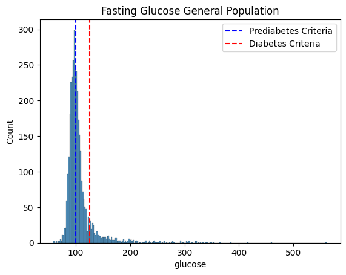

```python
# detetermine the overall metrics
nhanes['glucose'].describe()
# plot glucose
sns.histplot(nhanes, x = 'glucose')
plt.axvline(x = 100, color = 'blue', linestyle = '--', label = 'Prediabetes Criteria')
plt.axvline(x = 126, color = 'red', linestyle = '--', label = 'Diabetes Criteria')
plt.title('Fasting Glucose General Population')
plt.legend()
plt.show()
```

In the population sampled by NHANES, the mean fasting glucose is approximately 107.7 mg/dl, with a standard deviation of approximately 32.16 mg/dl. The cutoff criteria for prediabetes and diabetes fasting glucose levels are 100 and 126 respectively. This indicates that a large segment of the population is either diabetic or at risk of developing diabetes accorrding to their bloodwork. Fasting glucose appears to be positively skewed, with a median glucose level of 100.

```
diabetes_diag
Not Diabetic    2964
Diabetic         409
Borderline       124
Do Not Know        1
Name: count, dtype: int64
```

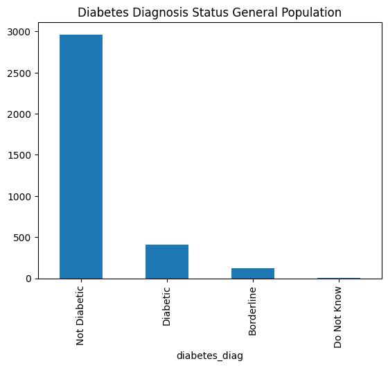

```python
# Visualizing Diabetes diagnosis
diagnosis_levels = nhanes['diabetes_diag'].value_counts()
diagnosis_levels

diagnosis_levels.plot(kind = 'bar')
plt.title('Diabetes Diagnosis Status General Population')
plt.show()
```

Most NHANES respondents report that they have not been diagnosed with diabetes. Approximately 500 respondents were diagnosed with diabetes, are borderline diabetic or do not know their diagnosis status. Of those not diagnosed with diabetes, it could be relevant to identify those that meet glucose criteria for diabetes or prediabetes (below).

### Determining Underdiagnosed/At Risk Population

```python
# finding the at risk population (prediabetic)
nhanes_atrisk = nhanes[nhanes['diabetes_diag'] == 'Not Diabetic']

nhanes_atrisk = nhanes_atrisk[nhanes_atrisk['glucose'] > 100]

nhanes_atrisk.info()
```

```
<class 'pandas.core.frame.DataFrame'>
Index: 1228 entries, 0 to 3492
Data columns (total 20 columns):
 #   Column          Non-Null Count  Dtype
---  ------          --------------  -----
 0   Unnamed: 0      1228 non-null   int64
 1   seqn            1228 non-null   float64
 2   gender          1228 non-null   object
 3   age             1228 non-null   float64
 4   income_status   1228 non-null   float64
 5   race_eth        1228 non-null   object
 6   recall_status   1228 non-null   object
 7   total_calories  1000 non-null   float64
 8   total_protein   1000 non-null   float64
 9   total_carbs     1000 non-null   float64
 10  total_sugars    1000 non-null   float64
 11  total_fiber     1000 non-null   float64
 12  ratio_protein   1000 non-null   float64
 13  ratio_sugars    1000 non-null   float64
 14  ratio_carbs     1000 non-null   float64
 15  ratio_fiber     1000 non-null   float64
 16  bmi             1228 non-null   float64
 17  waist           1228 non-null   float64
 18  diabetes_diag   1228 non-null   object
 19  glucose         1228 non-null   float64
dtypes: float64(15), int64(1), object(4)
memory usage: 201.5+ KB
```

```
count    1228.000000
mean      111.598534
std        18.983866
min       101.000000
25%       103.000000
50%       107.000000
75%       113.000000
max       329.000000
Name: glucose, dtype: float64
```

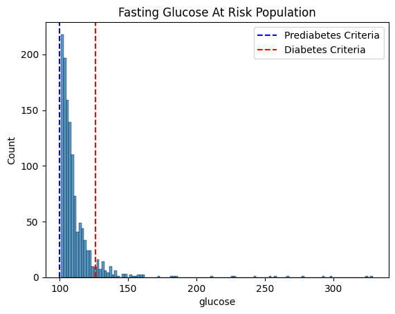

```python
# visualizing blood glucose levels in at risk population
nhanes_atrisk['glucose'].describe()
# plot glucose
sns.histplot(nhanes_atrisk, x = 'glucose')
plt.axvline(x = 100, color = 'blue', linestyle = '--', label = 'Prediabetes Criteria')
plt.axvline(x = 126, color = 'red', linestyle = '--', label = 'Diabetes Criteria')
plt.title('Fasting Glucose At Risk Population')
plt.legend()
plt.show()
```

There are 1228 respondents that meet this criteria for prediabetic/diabetic according to their fasting glucose who have not received a diabetes diagnosis. This population could be relevant in future explorations. 228 of these respondents did not undergo the nutritional analysis. Most of these patients meet the criteria for prediabetes, with a median blood glucose of 107. For this population, blood glucose levels are positively skewed.

### Determining Undiagnosed Population

```python
# finding undiagnosed population
nhanes_undiagnosed = nhanes[nhanes['diabetes_diag'] == 'Not Diabetic']

nhanes_undiagnosed = nhanes_undiagnosed[nhanes_undiagnosed['glucose'] > 126]

nhanes_undiagnosed.info()
```

```
<class 'pandas.core.frame.DataFrame'>
Index: 98 entries, 7 to 3381
Data columns (total 20 columns):
 #   Column          Non-Null Count  Dtype
---  ------          --------------  -----
 0   Unnamed: 0      98 non-null     int64
 1   seqn            98 non-null     float64
 2   gender          98 non-null     object
 3   age             98 non-null     float64
 4   income_status   98 non-null     float64
 5   race_eth        98 non-null     object
 6   recall_status   98 non-null     object
 7   total_calories  75 non-null     float64
 8   total_protein   75 non-null     float64
 9   total_carbs     75 non-null     float64
 10  total_sugars    75 non-null     float64
 11  total_fiber     75 non-null     float64
 12  ratio_protein   75 non-null     float64
 13  ratio_sugars    75 non-null     float64
 14  ratio_carbs     75 non-null     float64
 15  ratio_fiber     75 non-null     float64
 16  bmi             98 non-null     float64
 17  waist           98 non-null     float64
 18  diabetes_diag   98 non-null     object
 19  glucose         98 non-null     float64
dtypes: float64(15), int64(1), object(4)
memory usage: 16.1+ KB
```

```
count     98.000000
mean     154.693878
std       45.891492
min      127.000000
25%      131.000000
50%      137.000000
75%      152.000000
max      329.000000
Name: glucose, dtype: float64
```

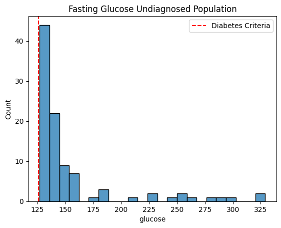

```python
# visualizing blood glucose levels in undiagnosed population
nhanes_undiagnosed['glucose'].describe()
# plot glucose
sns.histplot(nhanes_undiagnosed, x = 'glucose')
plt.axvline(x = 126, color = 'red', linestyle = '--', label = 'Diabetes Criteria')
plt.title('Fasting Glucose Undiagnosed Population')
plt.legend()
plt.show()
```

There are 98 respondents with fasting glucose high enough to meet the criteria for diabetes, despite not ever receiving a diabetes diagnosis. The glucose levels in these respondents is skewed positively and has a median of 137. This population is critical to determine factors contributing to their glucose and diabetes diagnosis status, as they remain most at risk for side effects of uncontrolled diabetes.

## Assessing Correlations With Fasting Glucose

Purpose of this section:

- Determine skewedness of variables relevant to broad analyses (bmi, waist and glucose most importantly)
- Build correlation matrix to visualize associations between BMI, waist circumference and glucose levels in general, at risk and undiagnosed respondent populations

### Overall Population

```python
# nhanes skew check
nhanes.skew(numeric_only = True)

# glucose is positively skewed
glucoseLog = np.log(nhanes['glucose'])
glucoseLog.skew()
    # log reduces its skew

corrcols = ['age', 'bmi', 'waist', 'glucose']
```

```
Unnamed: 0         0.009669
seqn               0.000055
age               -0.289848
income_status     -0.088911
total_calories     1.576063
total_protein      1.892809
total_carbs        1.943751
total_sugars       2.845679
total_fiber        1.965823
ratio_protein     24.369276
ratio_sugars      15.016363
ratio_carbs       11.170304
ratio_fiber       29.666416
bmi                1.083037
waist              0.485488
glucose            4.903948
dtype: float64
```

```
2.6396034570008378
```

In this instance, glucose, ratio_protein, ratio_sugars, ratio_carbs and ratio_fiber are all positively skewed. Logarithmic scaling reduces the skew for fasting glucose.

We cannot assess macronutrient involvement at this point in analysis, as not all respondents underwent nutritional analysis. Further, analyses including income status will be performed later on in the EDA and are not primary target of analysis in this section.

|  | age | bmi | waist | glucose |
| --- | --- | --- | --- | --- |
| age | 1.000000 | 0.169504 | 0.327498 | 0.380169 |
| bmi | 0.169504 | 1.000000 | 0.906754 | 0.297836 |
| waist | 0.327498 | 0.906754 | 1.000000 | 0.401125 |
| glucose | 0.380169 | 0.297836 | 0.401125 | 1.000000 |

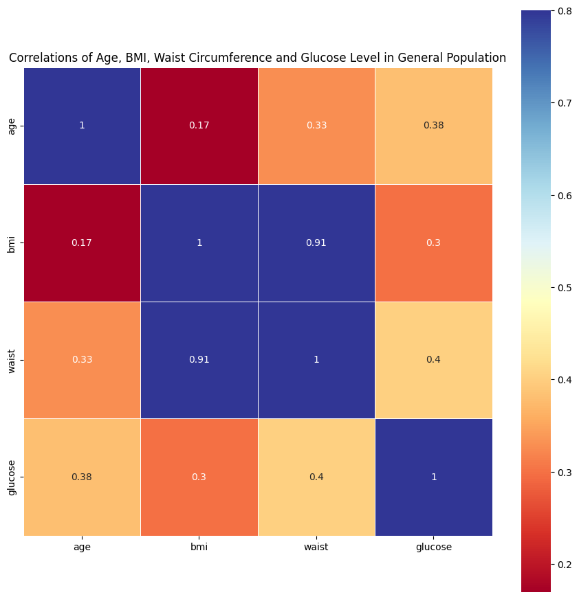

```python
# selecting for columns we want to examine
nhanes_corr = nhanes[corrcols]

# Creates a correlation matrix
corrmat = nhanes_corr.corr(method = 'spearman')
corrmat

# Heatmap of correlation matrix
f, ax = plt.subplots(figsize = (11,11))
sns.heatmap(corrmat, vmax = .8, square = True, annot = True, cmap = 'RdYlBu', linewidths = .5 )
plt.title('Correlations of Age, BMI, Waist Circumference and Glucose Level in General Population')
plt.show()
```

### At Risk Population

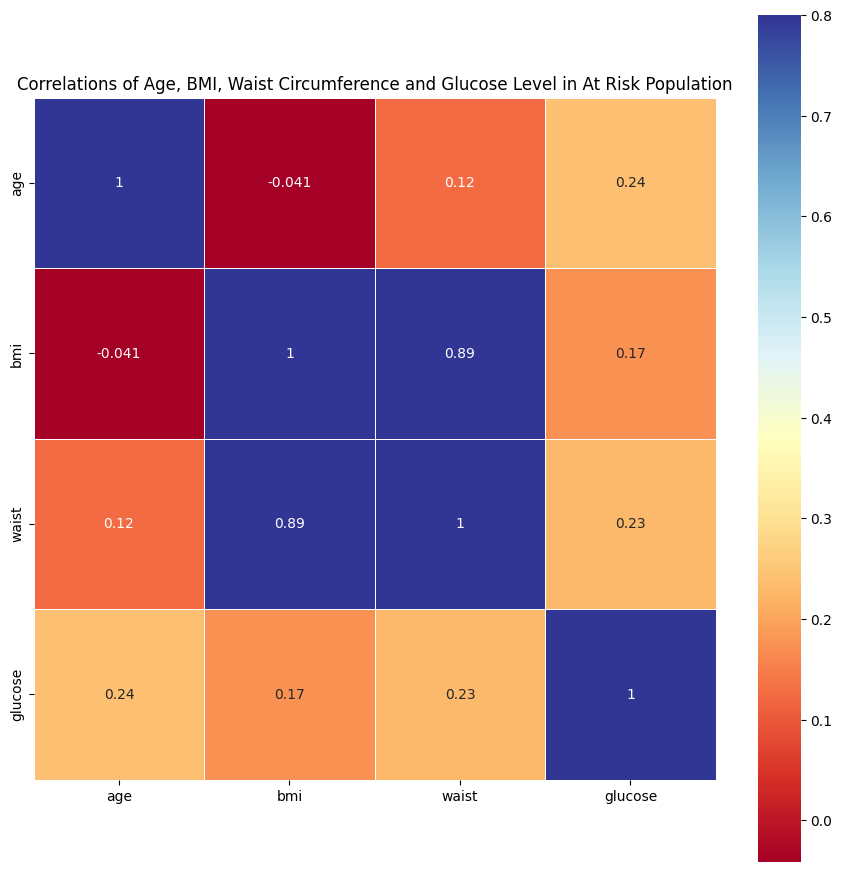

```python
# selecting for columns we want to examine
atrisk_corr = nhanes_atrisk[corrcols]

# Creates a correlation matrix
corrmat = atrisk_corr.corr(method = 'spearman')

# Heatmap of correlation matrix
f, ax = plt.subplots(figsize = (11,11))
sns.heatmap(corrmat, vmax = .8, square = True, annot = True, cmap = 'RdYlBu', linewidths = .5 )
plt.title('Correlations of Age, BMI, Waist Circumference and Glucose Level in At Risk Population')
plt.show()
```

In the at risk population that exhibits high glucose fasting levels despite lacking a diabetes diagnosis, fasting glucose is weakly correlated with bmi, waist and age (.17, .23 and .24 respectively). Relative to the general population, this indicates that while waist circumference and age still outperform BMI as a risk factor for high fasting glucose, all three variables are not as strongly correlated with higher glucose.

### Undiagnosed Population

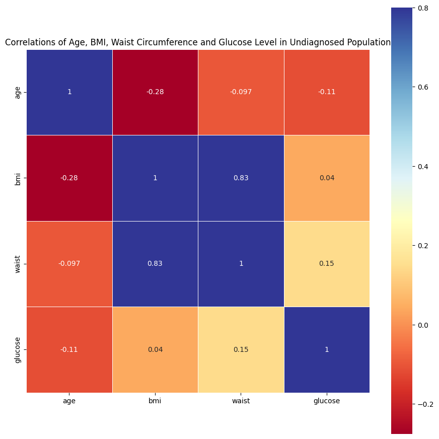

```python
# selecting for columns we want to examine
undiagnosed_corr = nhanes_undiagnosed[corrcols]

# Creates a correlation matrix
corrmat = undiagnosed_corr.corr(method = 'spearman')

# Heatmap of correlation matrix
f, ax = plt.subplots(figsize = (11,11))
sns.heatmap(corrmat, vmax = .8, square = True, annot = True, cmap = 'RdYlBu', linewidths = .5 )
plt.title('Correlations of Age, BMI, Waist Circumference and Glucose Level in Undiagnosed Population')
plt.show()
```

In the undiagnosed population that exhibits high glucose fasting levels meeting threshold for diabetes despite lacking a diabetes diagnosis, fasting glucose is weakly positively correlated waist circumference (.15). There is a .04 correlation between blood glucose levels and BMI for this population, much lower than that of the at risk and general populations. Age has a weak negative correlation with glucose levels for this population, which diverges from trends seen in at risk and general populations (having weak or moderate positive correlations).

### Aim 1 Overall Conclusions:

There are approximately 1200 respondents at risk for diabetes diagnosis that have not received one. There are approximately 100 respondents that should receive a diabetes diagnosis on the basis of their fasting glucose levels that have not received one. Waist circumference generally correlates stronger with glucose levels than BMI in general, at risk and undiagnosed populations. This indicates that it could be a better assessment tool than BMI for determining diabetes risk.

# Aim 2: Assess diabetes outcomes and trends across subpopulations

Purpose of this section:

- Build visualizations to determine gender balance for general, at risk and undiagnosed patient populations
- Build visualizations to determine trends of glucose levels for male and female respondents in overall, at risk and undiagnosed patient populations
- Build visualizations to determine race/ethnicity demographic for general, at risk and undiagnosed patient populations
- Build visualizations to determine trends of glucose levels across reported racial/ethnic backgrounds in overall, at risk and undiagnosed patient populations
- Assess correlations of socioeconomic status with glucose levels in overall, at risk and undiagnosed patient populations.

## Overall Population: Gender, Race/Ethnicity, Socioeconomic Status

### Gender

```
gender
female    1916
male      1582
Name: count, dtype: int64
```

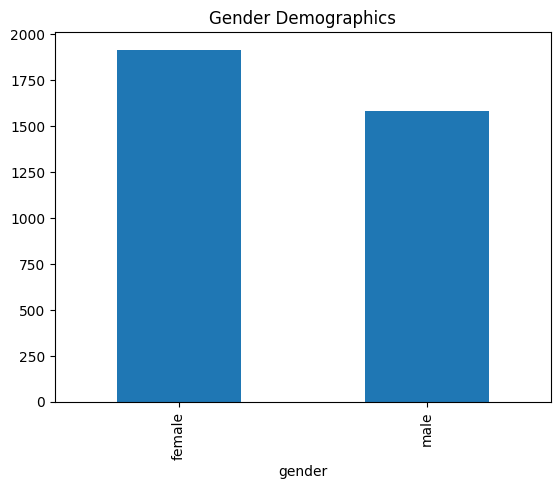

```python
# examine gender breakdown in overall population
gender_counts = nhanes['gender'].value_counts()

gender_counts

gender_counts.plot(kind = 'bar')
plt.title('Gender Demographics')
plt.show()
```

The gender breakdown of the general NHANES respondent population is fairly even, with approximately 300 more female respondents than male.

```
Female Fasting Glucose Levels
```

```
count    1916.000000
mean      104.204593
std        27.482630
min        59.000000
25%        92.000000
50%        98.000000
75%       106.000000
max       460.000000
Name: glucose, dtype: float64
```

```
Male Fasting Glucose Levels
```

```
count    1582.000000
mean      111.877370
std        36.610539
min        59.000000
25%        96.000000
50%       103.000000
75%       112.000000
max       561.000000
Name: glucose, dtype: float64
```

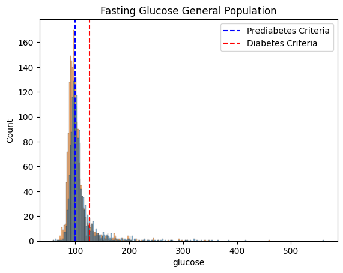

```python
# gender analysis for glucose

female_glucose = nhanes[nhanes['gender'] == 'female']
male_glucose = nhanes[nhanes['gender'] == 'male']

print('Female Fasting Glucose Levels')
female_glucose['glucose'].describe()
print('\nMale Fasting Glucose Levels')
male_glucose['glucose'].describe()

sns.histplot(nhanes, x = 'glucose', hue = 'gender')
plt.title('Fasting Glucose General Population')
plt.axvline(x = 100, color = 'blue', linestyle = '--', label = 'Prediabetes Criteria')
plt.axvline(x = 126, color = 'red', linestyle = '--', label = 'Diabetes Criteria')
plt.legend()
plt.show()
```

The median fasting glucose levels appear to be slightly higher in male respondents in the general NHANES survey population, with a median glucose level of 98 for female respondents and 103 for male. Both genders see high positive skew in their distributions. Further analysis within at risk and undiagnosed populations could reveal starker gendered differences.

### Race/Ethnicity

```
Race/Ethnicity of Respondents to NHANES
```

```
race_eth
Non-Hispanic White                     2019
Other Hispanic                          389
Non-Hispanic Black                      375
Mexican American                        294
Other Race - Including Multi-Racial     222
Non-Hispanic Asian                      199
Name: count, dtype: int64
```

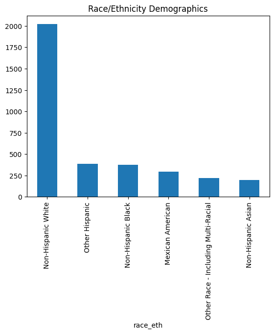

```python
# examine race/ethnicity breakdown in overall population
race_eth_counts = nhanes['race_eth'].value_counts()

print('Race/Ethnicity of Respondents to NHANES')
race_eth_counts

race_eth_counts.plot(kind = 'bar')
plt.title('Race/Ethnicity Demographics')
plt.show()
```

Most respondents identify as 'Non-Hispanic White', with over 2000 respondents. The next largest groups surveyed include respondents from 'Other Hispanic' (meaning those identify as Hispanic but not Mexican American) and 'Non-Hispanic Black' bacgkrounds, with 389 and 375 respondents respectively.

```
Fasting Glucose Metrics Across Respondent Reported Race/Ethnicity
```

| race_eth | count | mean | std | min | 25% | 50% | 75% | max |
| --- | --- | --- | --- | --- | --- | --- | --- | --- |
| Mexican American | 294.0 | 111.394558 | 39.450934 | 69.0 | 94.0 | 101.0 | 111.0 | 348.0 |
| Non-Hispanic Asian | 199.0 | 109.562814 | 41.454671 | 73.0 | 93.0 | 100.0 | 111.0 | 561.0 |
| Non-Hispanic Black | 375.0 | 109.077333 | 41.715126 | 72.0 | 92.0 | 99.0 | 109.0 | 460.0 |
| Non-Hispanic White | 2019.0 | 106.672610 | 27.217843 | 59.0 | 94.0 | 100.0 | 109.0 | 354.0 |
| Other Hispanic | 389.0 | 107.956298 | 31.506433 | 72.0 | 93.0 | 99.0 | 109.0 | 322.0 |
| Other Race - Including Multi-Racial | 222.0 | 107.306306 | 35.699929 | 63.0 | 93.0 | 99.0 | 107.0 | 417.0 |

```
Distribution of Fasting Glucose Levels Across Respondent Reported Race/Ethnicity
```

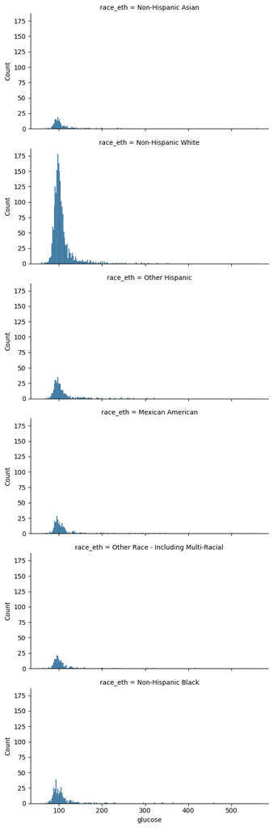

```python
# glucose levels across race/ethnicity

print('\n')
print('Fasting Glucose Metrics Across Respondent Reported Race/Ethnicity')
nhanes.groupby('race_eth')['glucose'].describe()


print('\n')
print('Distribution of Fasting Glucose Levels Across Respondent Reported Race/Ethnicity')
sns.displot(nhanes, x = 'glucose', row = 'race_eth', kind = 'hist', height = 3, aspect = 2)
plt.show()
```

Among those identifying as 'Mexican American', the median blood glucose is approximately 101, with a positive skew overall. Among those identifying as 'Non-Hispanic Asian', the median blood glucose is approximately 100, with a positive skew overall. Among those identifying as 'Non-Hispanic Black', the median blood glucose is approximately 99, with a positive skew overall. Among those idnentifying as 'Non-Hispanic White', the median blood glucose is approximatley 100, with a positive skew overall. Among those identifying as 'Other Hispanic', the median blood glucose is approximately 99, with a positive skew overall. Among those idnentifying as 'Other Race - Including Multi-Racial', the median blood glucose is approximatley 99, with a positive skew overall.

### Socioeconomic Status

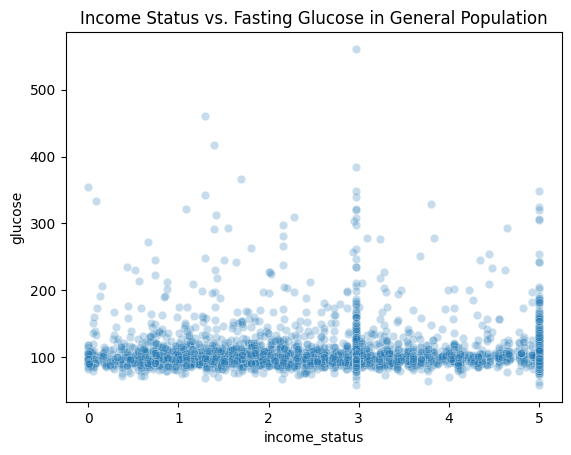

```
Correlation between Income and Fasting Glucose
```

|  | glucose | income_status |
| --- | --- | --- |
| glucose | 1.000000 | -0.011613 |
| income_status | -0.011613 | 1.000000 |

```python
# plotting glucose vs. socioeconomic status
sns.scatterplot(nhanes, x = 'income_status', y = 'glucose', alpha = .25)
plt.title('Income Status vs. Fasting Glucose in General Population')
plt.show()


cols = ['glucose', 'income_status']
# selecting for columns we want to examine
nhanes_ses_corr = nhanes[cols]

# Creates a correlation matrix
corrmat = nhanes_ses_corr.corr(method = 'spearman')


print('\nCorrelation between Income and Fasting Glucose')
corrmat
```

## At Risk Population: Gender, Race/Ethnicity, Socioeconomic Status

### Gender

```
gender
male      651
female    577
Name: count, dtype: int64
```

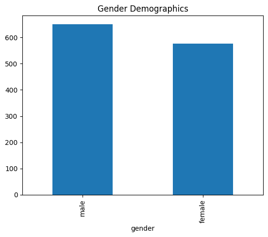

```python
# examine gender breakdown in overall population
gender_counts = nhanes_atrisk['gender'].value_counts()

gender_counts

gender_counts.plot(kind = 'bar')
plt.title('Gender Demographics')
plt.show()
```

The gender breakdown of the general NHANES at risk for diabetes respondent population with approximately 80 more male respondents than female. Important to note is that despite female respondents outnumbering male respondents in the general NHANES population, male respondents outnumber female respondents in the at risk population. This could be an indication that male respondents are at slightly greater risk than female respondents, especially when examining their overall blood glucose levels.

```
Female Fasting Glucose Levels
```

```
count    577.000000
mean     111.213172
std       18.479473
min      101.000000
25%      103.000000
50%      106.000000
75%      113.000000
max      329.000000
Name: glucose, dtype: float64
```

```
Male Fasting Glucose Levels
```

```
count    651.000000
mean     111.940092
std       19.427762
min      101.000000
25%      104.000000
50%      107.000000
75%      113.000000
max      325.000000
Name: glucose, dtype: float64
```

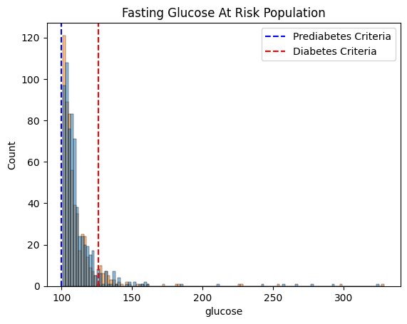

```python
# gender analysis for glucose at risk populations

female_glucose = nhanes_atrisk[nhanes_atrisk['gender'] == 'female']
male_glucose = nhanes_atrisk[nhanes_atrisk['gender'] == 'male']

print('Female Fasting Glucose Levels')
female_glucose['glucose'].describe()
print('\nMale Fasting Glucose Levels')
male_glucose['glucose'].describe()

sns.histplot(nhanes_atrisk, x = 'glucose', hue = 'gender')
plt.title('Fasting Glucose At Risk Population')
plt.axvline(x = 100, color = 'blue', linestyle = '--', label = 'Prediabetes Criteria')
plt.axvline(x = 126, color = 'red', linestyle = '--', label = 'Diabetes Criteria')
plt.legend()
plt.show()
```

The median fasting glucose for at risk respondents levels appear to be slightly higher in male respondents in the at risk for diabetes NHANES survey population, with a median glucose level of 106 for female respondents and 107 for male. Both these distributions are skewed positively.

### Race/Ethnicity

```
Race/Ethnicity of Respondents At Risk for Diabetes
```

```
race_eth
Non-Hispanic White                     751
Other Hispanic                         127
Non-Hispanic Black                     120
Mexican American                       108
Other Race - Including Multi-Racial     63
Non-Hispanic Asian                      59
Name: count, dtype: int64
```

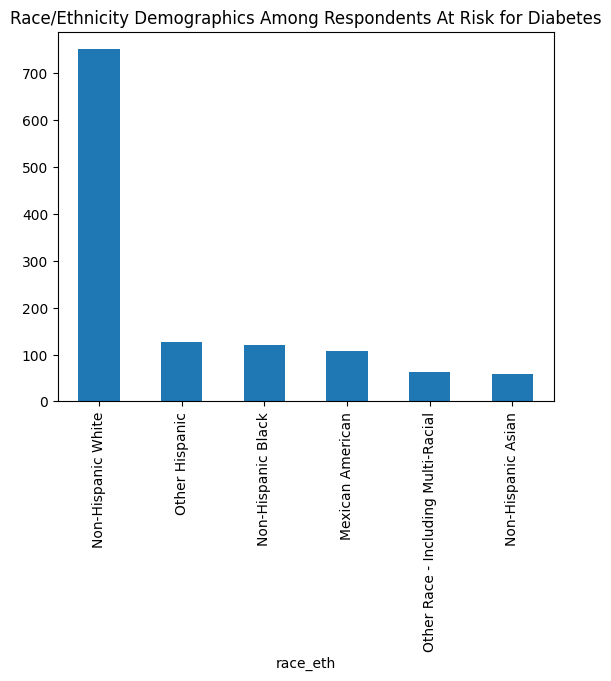

```python
# examine race/ethnicity breakdown in at risk population
race_eth_counts = nhanes_atrisk['race_eth'].value_counts()

print('Race/Ethnicity of Respondents At Risk for Diabetes')
race_eth_counts

race_eth_counts.plot(kind = 'bar')
plt.title('Race/Ethnicity Demographics Among Respondents At Risk for Diabetes')
plt.show()
```

This distribution of race/ethnic backgrounds among respondents at risk for diabetes appears similar to that of the general population, with 'Non-Hispanic White' making up the majority of respondents, followed by 'Other Hispanic' and 'Non-Hispanic Black'.

```
Fasting Glucose Metrics Across Respondent Reported Race/Ethnicity in At Risk Respondents
```

| race_eth | count | mean | std | min | 25% | 50% | 75% | max |
| --- | --- | --- | --- | --- | --- | --- | --- | --- |
| Mexican American | 108.0 | 114.962963 | 27.160281 | 101.0 | 104.0 | 108.5 | 114.25 | 292.0 |
| Non-Hispanic Asian | 59.0 | 110.338983 | 10.774507 | 101.0 | 103.0 | 106.0 | 113.50 | 159.0 |
| Non-Hispanic Black | 120.0 | 111.858333 | 15.626575 | 101.0 | 104.0 | 107.0 | 114.00 | 227.0 |
| Non-Hispanic White | 751.0 | 111.410120 | 19.419910 | 101.0 | 103.0 | 107.0 | 113.00 | 329.0 |
| Other Hispanic | 127.0 | 111.448819 | 17.317167 | 101.0 | 103.0 | 107.0 | 113.00 | 258.0 |
| Other Race - Including Multi-Racial | 63.0 | 109.063492 | 9.049814 | 101.0 | 103.0 | 107.0 | 110.00 | 149.0 |

```
Distribution of Fasting Glucose Levels Across Respondent Reported Race/Ethnicity in At Risk Respondents
```

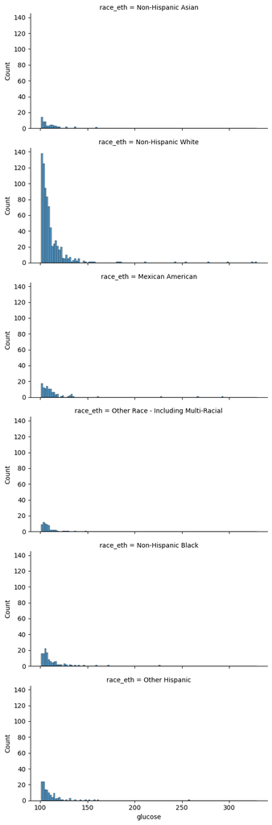

```python
# glucose levels across race/ethnicity in at risk populations

print('\n')
print('Fasting Glucose Metrics Across Respondent Reported Race/Ethnicity in At Risk Respondents')
nhanes_atrisk.groupby('race_eth')['glucose'].describe()


print('\n')
print('Distribution of Fasting Glucose Levels Across Respondent Reported Race/Ethnicity in At Risk Respondents')
sns.displot(nhanes_atrisk, x = 'glucose', row = 'race_eth', kind = 'hist', height = 3, aspect = 2)
plt.show()
```

Among those identifying as 'Mexican American', the median blood glucose is approximately 108.5, with a positive skew overall. Among those identifying as 'Non-Hispanic Asian', the median blood glucose is approximately 106, with a positive skew overall. Among those identifying as 'Non-Hispanic Black', the median blood glucose is approximately 107, with a positive skew overall. Among those idnentifying as 'Non-Hispanic White', the median blood glucose is approximatley 107, with a positive skew overall. Among those identifying as 'Other Hispanic', the median blood glucose is approximately 107, with a positive skew overall. Among those idnentifying as 'Other Race - Including Multi-Racial', the median blood glucose is approximatley 107, with a positive skew overall.

Across all reported race/ethnicities, the median fasting glucose level is fairly consistent. Extreme values vary across different subpopulations, with the respondent producing the greatest measure of blood glucose being 329 and identifying as 'Non Hispanic White'.

### Socioeconomic Status

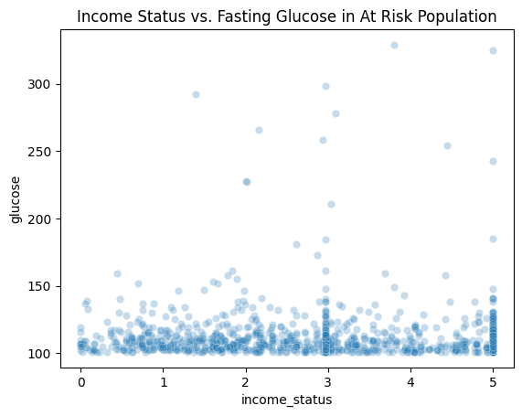

```
Correlation between Income and Fasting Glucose in At Risk Population
```

|  | glucose | income_status |
| --- | --- | --- |
| glucose | 1.000000 | -0.080405 |
| income_status | -0.080405 | 1.000000 |

```python
# plotting glucose vs. socioeconomic status
sns.scatterplot(nhanes_atrisk, x = 'income_status', y = 'glucose', alpha = .25)
plt.title('Income Status vs. Fasting Glucose in At Risk Population')
plt.show()


cols = ['glucose', 'income_status']
# selecting for columns we want to examine
nhanes_atrisk_ses_corr = nhanes_atrisk[cols]

# Creates a correlation matrix
corrmat = nhanes_atrisk_ses_corr.corr(method = 'spearman')


print('\nCorrelation between Income and Fasting Glucose in At Risk Population')
corrmat
```

There is a weak, negative correlation between income/socioeconomic status and fasting glucose in the at risk NHANES population. Despite it being weak (-.08), it is greater than the correlation between socioeconomic status/income status and glucose levels in the general population. Regardless, income status is likely not a strong predictor of diabetes risk in these populations.

## Undiagnosed Population: Gender, Race/Ethnicity, Socioeconomic Status

### Gender

```
gender
female    52
male      46
Name: count, dtype: int64
```

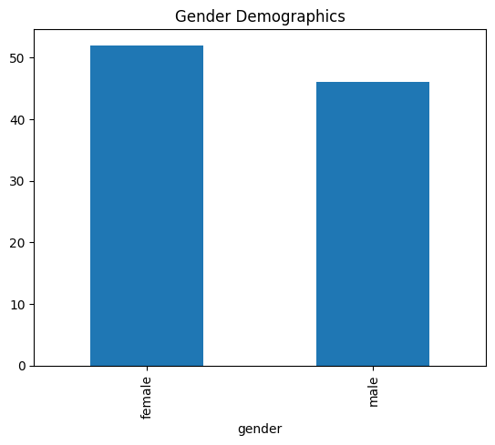

```python
# examine gender breakdown in overall population
gender_counts = nhanes_undiagnosed['gender'].value_counts()

gender_counts

gender_counts.plot(kind = 'bar')
plt.title('Gender Demographics')
plt.show()
```

In the undiagnosed population, there are 52 female respondents and 46 male respondents. This is fairly even and consistent with the gender distribution in the general NHANES respondent population. This is contrary to the gender distribution seen in the at risk populaiton, where male respondents slightly outnumbered female respondents.

```
Undiagnosed Female Fasting Glucose Levels
```

```
count     52.000000
mean     150.288462
std       42.526272
min      127.000000
25%      130.000000
50%      134.000000
75%      146.250000
max      329.000000
Name: glucose, dtype: float64
```

```
Male Fasting Glucose Levels
```

```
count     46.000000
mean     159.673913
std       49.419319
min      127.000000
25%      132.000000
50%      138.500000
75%      157.250000
max      325.000000
Name: glucose, dtype: float64
```

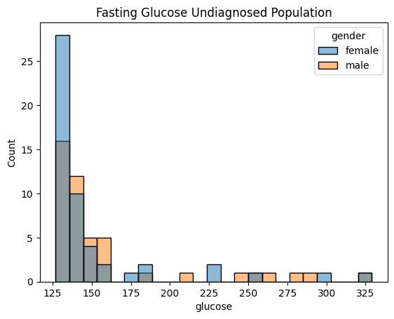

```python
# gender analysis for glucose at risk populations

female_glucose = nhanes_undiagnosed[nhanes_undiagnosed['gender'] == 'female']
male_glucose = nhanes_undiagnosed[nhanes_undiagnosed['gender'] == 'male']

print('Undiagnosed Female Fasting Glucose Levels')
female_glucose['glucose'].describe()
print('\nMale Fasting Glucose Levels')
male_glucose['glucose'].describe()

sns.histplot(nhanes_undiagnosed, x = 'glucose', hue = 'gender')
plt.title('Fasting Glucose Undiagnosed Population')
plt.show()
```

The median fasting glucose for undiagnosed respondents levels appear to be slightly higher in male respondents in the at risk for diabetes NHANES survey population, with a median glucose level of 134 for female respondents and 138 for male. Both these distributions are skewed positively. These trends are similar to both the at risk and general populations.

### Race/Ethnicity

```
Race/Ethnicity of Undiagnosed Respondents
```

```
race_eth
Non-Hispanic White                     55
Mexican American                       12
Other Hispanic                         11
Non-Hispanic Black                     11
Non-Hispanic Asian                      5
Other Race - Including Multi-Racial     4
Name: count, dtype: int64
```

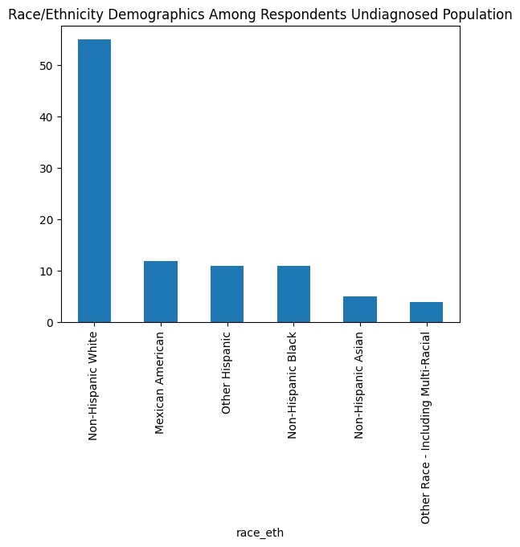

```python
# examine race/ethnicity breakdown in undiagnosed population
race_eth_counts = nhanes_undiagnosed['race_eth'].value_counts()

print('Race/Ethnicity of Undiagnosed Respondents')
race_eth_counts

race_eth_counts.plot(kind = 'bar')
plt.title('Race/Ethnicity Demographics Among Respondents Undiagnosed Population')
plt.show()
```

This distribution of race/ethnic backgrounds among undiagnosed respondents appears similar to that of the general population and at risk population, with 'Non-Hispanic White' making up the majority of those at risk (55). There are 12 undiagnosed respondents identifying as 'Mexican American', 11 identifying as 'Other Hispanic', 11 identifying as 'Non-Hispanic Black', 5 identifying as 'Non-Hispanic Asian' and 4 identifying as 'Other Race - Including Multi-Racial'.

```
Fasting Glucose Metrics Across Respondent Reported Race/Ethnicity in Undiagnosed Respondents
```

| race_eth | count | mean | std | min | 25% | 50% | 75% | max |
| --- | --- | --- | --- | --- | --- | --- | --- | --- |
| Mexican American | 12.0 | 167.666667 | 59.072118 | 130.0 | 133.50 | 134.0 | 177.75 | 292.0 |
| Non-Hispanic Asian | 5.0 | 138.200000 | 12.657014 | 128.0 | 128.00 | 138.0 | 138.00 | 159.0 |
| Non-Hispanic Black | 11.0 | 148.727273 | 29.458754 | 128.0 | 132.00 | 137.0 | 152.50 | 227.0 |
| Non-Hispanic White | 55.0 | 156.345455 | 50.434122 | 127.0 | 130.00 | 138.0 | 150.00 | 329.0 |
| Other Hispanic | 11.0 | 152.636364 | 36.792045 | 127.0 | 132.00 | 143.0 | 155.00 | 258.0 |
| Other Race - Including Multi-Racial | 4.0 | 135.750000 | 9.776673 | 127.0 | 129.25 | 133.5 | 140.00 | 149.0 |

```
Distribution of Fasting Glucose Levels Across Respondent Reported Race/Ethnicity in Undiagnosed Respondents
```

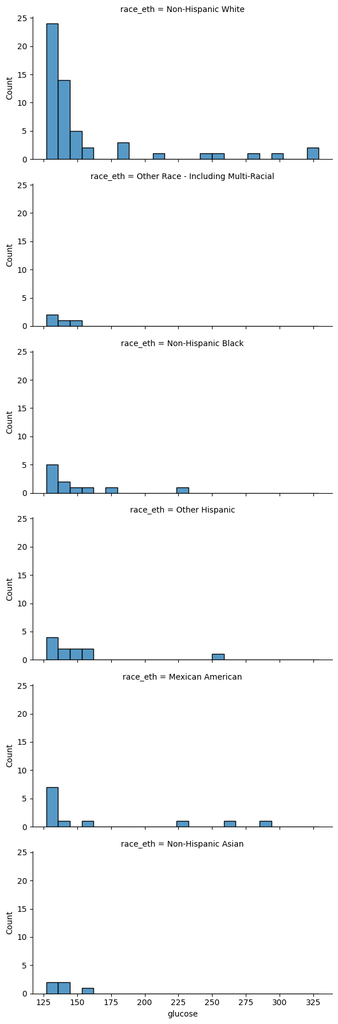

```python
# glucose levels across race/ethnicity in undiagnosed populations

print('\n')
print('Fasting Glucose Metrics Across Respondent Reported Race/Ethnicity in Undiagnosed Respondents')
nhanes_undiagnosed.groupby('race_eth')['glucose'].describe()


print('\n')
print('Distribution of Fasting Glucose Levels Across Respondent Reported Race/Ethnicity in Undiagnosed Respondents')
sns.displot(nhanes_undiagnosed, x = 'glucose', row = 'race_eth', kind = 'hist', height = 3, aspect = 2)
plt.show()
```

Among those identifying as 'Mexican American', the median blood glucose is approximately 134, with a positive skew overall. Among those identifying as 'Non-Hispanic Asian', the median blood glucose is approximately 138, with a positive skew overall. Among those identifying as 'Non-Hispanic Black', the median blood glucose is approximately 137, with a positive skew overall. Among those idnentifying as 'Non-Hispanic White', the median blood glucose is approximatley 138, with a positive skew overall. Among those identifying as 'Other Hispanic', the median blood glucose is approximately 143, with a positive skew overall. Among those idnetifying as 'Other Race - Including Multi-Racial', the median blood glucose is approximatley 133.5, with a positive skew overall.

All these subpopulations exhibit slightly positive skews. Some contain very few subjects, for example respondents identifying as 'Other Race - Including Multi-Racial' only has 4 respondents. This limits the ability to draw many conclusions regarding undiagnosed patients identifying as 'Other Race - Including Multi-Racial'.

### Socioeconomic Status

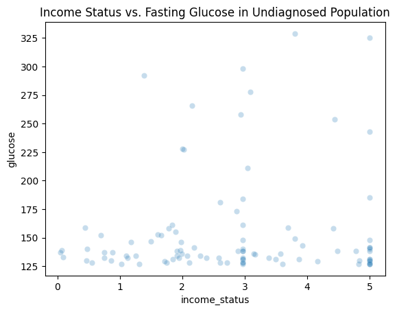

```
Correlation between Income and Fasting Glucose in Undiagnosed Population
```

|  | glucose | income_status |
| --- | --- | --- |
| glucose | 1.000000 | -0.020048 |
| income_status | -0.020048 | 1.000000 |

```python
# plotting glucose vs. socioeconomic status
sns.scatterplot(nhanes_undiagnosed, x = 'income_status', y = 'glucose', alpha = .25)
plt.title('Income Status vs. Fasting Glucose in Undiagnosed Population')
plt.show()


cols = ['glucose', 'income_status']
# selecting for columns we want to examine
nhanes_undiagnosed_ses_corr = nhanes_undiagnosed[cols]

# Creates a correlation matrix
corrmat = nhanes_undiagnosed_ses_corr.corr(method = 'spearman')


print('\nCorrelation between Income and Fasting Glucose in Undiagnosed Population')
corrmat
```

There is a weak, negative correlation between income and fasting glucose among undiagnosed patients (-.02). This indicates that socioeconomic status is not a strong predictor of diabetes risk among undiagnosed patients.

### Aim 2 Overall Conclusions:

Gender distribution is approximately even across general, at risk and undiagnosed NHANES respondent populations. Male respondents exhibit slightly higher fasting glucose scores and are slightly overrepresented in at the risk population, indicating that they might be at a slightly higher risk for developing prediabetes or diabetes.

Socioeconomic/income status did not correlate strongly with fasting glucose in general, at risk and undiagnosed populations. This indicates that income status is likely not a clear risk factor for diabetes, despite theories that access to greater income would support healthier lifestyle choices and increase preventative care utilization.

# Aim 3: Compare how BMI and other medical assessment tools determine diabetes risk across patient subpopulations

## Assessing Waist Circumference vs. BMI Correlation with Fasting Glucose Across Gender, Race/Ethnicity

Purpose of this section:

- Build correlation matrices to determine BMI and waist circumference associations with glucose levels for male and female respondents in general, at risk and undiagnosed populations.
- Build correlation matrices to determine BMI and waist circumference associations with glucose levels for all reported racial/ethnic backgrounds in general, at risk and undiagnosed populations.

Note: Since in Aim 2 we determined that socioeconomic status is not strongly correlated with fasting glucose in any NHANES population, any analysis pertaining to it's involvement in assessing diabetes risk would not be fruitful or relevant.

### Gender: General Population

|  | age | bmi | waist | glucose |
| --- | --- | --- | --- | --- |
| age | 1.000000 | 0.151345 | 0.285333 | 0.378912 |
| bmi | 0.151345 | 1.000000 | 0.920830 | 0.303345 |
| waist | 0.285333 | 0.920830 | 1.000000 | 0.381146 |
| glucose | 0.378912 | 0.303345 | 0.381146 | 1.000000 |

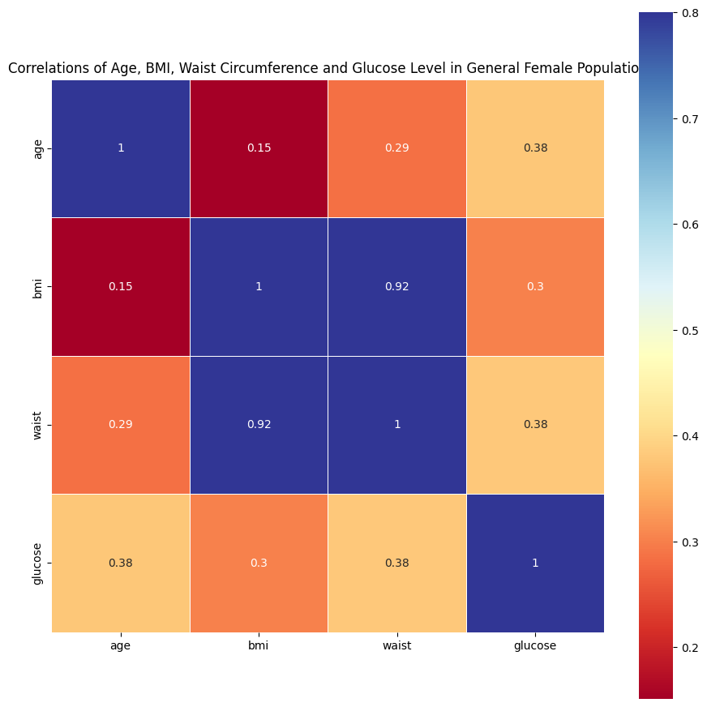

```python
# female general population
female_general = nhanes[nhanes['gender'] == 'female']

# selecting for columns we want to examine
nhanes_corr = female_general[corrcols]

# Creates a correlation matrix
corrmat = nhanes_corr.corr(method = 'spearman')
corrmat

# Heatmap of correlation matrix
f, ax = plt.subplots(figsize = (11,11))
sns.heatmap(corrmat, vmax = .8, square = True, annot = True, cmap = 'RdYlBu', linewidths = .5 )
plt.title('Correlations of Age, BMI, Waist Circumference and Glucose Level in General Female Population')
plt.show()
```

In the general population of female respondents, waist circumference exhibits a slightly higher moderate correlation (.38) with fasting glucose than bmi (.3).

|  | age | bmi | waist | glucose |
| --- | --- | --- | --- | --- |
| age | 1.000000 | 0.192601 | 0.383173 | 0.400189 |
| bmi | 0.192601 | 1.000000 | 0.920957 | 0.314406 |
| waist | 0.383173 | 0.920957 | 1.000000 | 0.390626 |
| glucose | 0.400189 | 0.314406 | 0.390626 | 1.000000 |

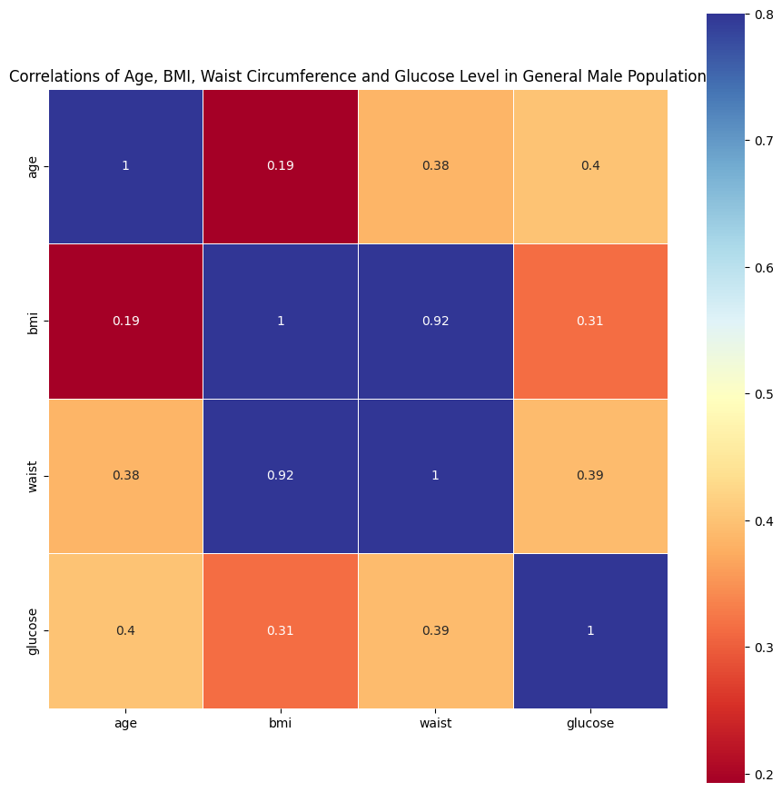

```python
# male general population
male_general = nhanes[nhanes['gender'] == 'male']

# selecting for columns we want to examine
nhanes_corr = male_general[corrcols]

# Creates a correlation matrix
corrmat = nhanes_corr.corr(method = 'spearman')
corrmat

# Heatmap of correlation matrix
f, ax = plt.subplots(figsize = (11,11))
sns.heatmap(corrmat, vmax = .8, square = True, annot = True, cmap = 'RdYlBu', linewidths = .5 )
plt.title('Correlations of Age, BMI, Waist Circumference and Glucose Level in General Male Population')
plt.show()
```

In the general population of emale respondents, waist circumference exhibits a slightly higher moderate correlation (.39) with fasting glucose than bmi (.31). This is similar to the trend seen for female respondents in the general population, with very similar correlation coefficients for waist circumference and bmi (.38 and .30 respectively).

### Gender: At Risk Population

|  | age | bmi | waist | glucose |
| --- | --- | --- | --- | --- |
| age | 1.000000 | -0.127645 | 0.005368 | 0.151063 |
| bmi | -0.127645 | 1.000000 | 0.912794 | 0.203537 |
| waist | 0.005368 | 0.912794 | 1.000000 | 0.222537 |
| glucose | 0.151063 | 0.203537 | 0.222537 | 1.000000 |

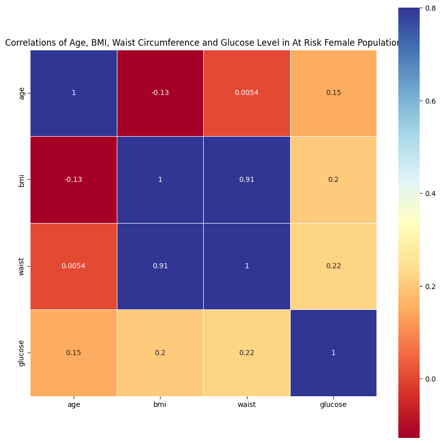

```python
# female at risk population
female_atrisk = nhanes_atrisk[nhanes_atrisk['gender'] == 'female']

# selecting for columns we want to examine
nhanes_corr = female_atrisk[corrcols]

# Creates a correlation matrix
corrmat = nhanes_corr.corr(method = 'spearman')
corrmat

# Heatmap of correlation matrix
f, ax = plt.subplots(figsize = (11,11))
sns.heatmap(corrmat, vmax = .8, square = True, annot = True, cmap = 'RdYlBu', linewidths = .5 )
plt.title('Correlations of Age, BMI, Waist Circumference and Glucose Level in At Risk Female Population')
plt.show()
```

Among female at risk respondents, waist circumference exhibits a sligthly higher weak positive correlation (.22) with fasting glucose levels than BMI (.2). This is similar to trends seen in the general population, however these correlations are much weaker than the general population (.38 and .30 respectively).

|  | age | bmi | waist | glucose |
| --- | --- | --- | --- | --- |
| age | 1.000000 | 0.019612 | 0.235185 | 0.328224 |
| bmi | 0.019612 | 1.000000 | 0.903545 | 0.151856 |
| waist | 0.235185 | 0.903545 | 1.000000 | 0.228150 |
| glucose | 0.328224 | 0.151856 | 0.228150 | 1.000000 |

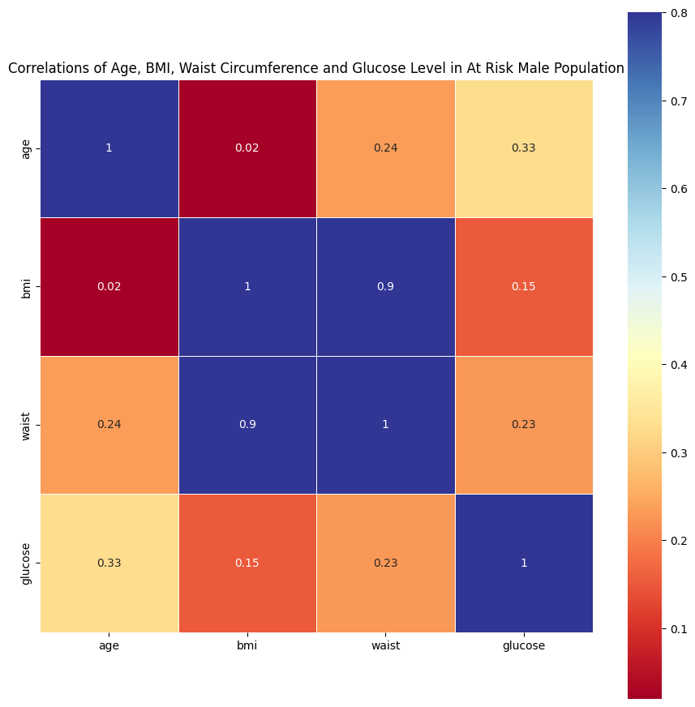

```python
# male at risk population
male_atrisk = nhanes_atrisk[nhanes_atrisk['gender'] == 'male']

# selecting for columns we want to examine
nhanes_corr = male_atrisk[corrcols]

# Creates a correlation matrix
corrmat = nhanes_corr.corr(method = 'spearman')
corrmat

# Heatmap of correlation matrix
f, ax = plt.subplots(figsize = (11,11))
sns.heatmap(corrmat, vmax = .8, square = True, annot = True, cmap = 'RdYlBu', linewidths = .5 )
plt.title('Correlations of Age, BMI, Waist Circumference and Glucose Level in At Risk Male Population')
plt.show()
```

Among male at risk respondents, waist circumference exhibits a higher weak positive correlation (.23) with fasting glucose levels than BMI (.15). This is similar to trends seen in the general population, however these correlations are much weaker than the general population (.39 and .31 respectively). This trend of correlation magnitude decreasing for both waist and BMI from general to at risk population is consistent across genders.

### Gender: Undiagnosed Population

|  | age | bmi | waist | glucose |
| --- | --- | --- | --- | --- |
| age | 1.000000 | -0.250150 | -0.099240 | -0.086415 |
| bmi | -0.250150 | 1.000000 | 0.803937 | 0.033666 |
| waist | -0.099240 | 0.803937 | 1.000000 | 0.068346 |
| glucose | -0.086415 | 0.033666 | 0.068346 | 1.000000 |

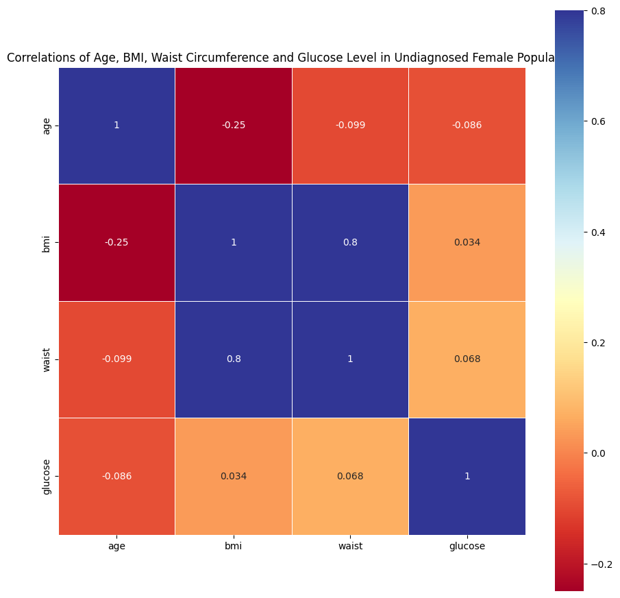

```python
# female undiagnosed population
female_undiagnosed = nhanes_undiagnosed[nhanes_undiagnosed['gender'] == 'female']

# selecting for columns we want to examine
nhanes_corr = female_undiagnosed[corrcols]

# Creates a correlation matrix
corrmat = nhanes_corr.corr(method = 'spearman')
corrmat

# Heatmap of correlation matrix
f, ax = plt.subplots(figsize = (11,11))
sns.heatmap(corrmat, vmax = .8, square = True, annot = True, cmap = 'RdYlBu', linewidths = .5 )
plt.title('Correlations of Age, BMI, Waist Circumference and Glucose Level in Undiagnosed Female Population')
plt.show()
```

Among female undiagnosed respondents, waist circumference exhibits a higher weak positive correlation (.068) with fasting glucose levels than BMI (.034). This is similar to trends seen in the general population and at risk population, however these correlations are much weaker than the general population and at risk population.

|  | age | bmi | waist | glucose |
| --- | --- | --- | --- | --- |
| age | 1.000000 | -0.268779 | -0.094177 | -0.200451 |
| bmi | -0.268779 | 1.000000 | 0.863938 | 0.241260 |
| waist | -0.094177 | 0.863938 | 1.000000 | 0.289977 |
| glucose | -0.200451 | 0.241260 | 0.289977 | 1.000000 |

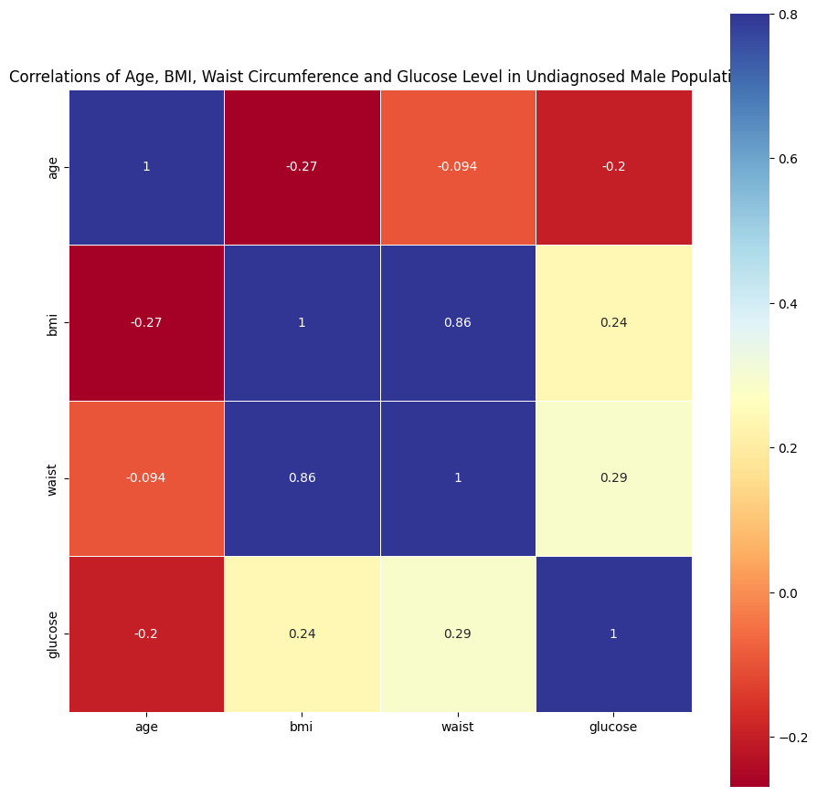

```python
# male undiagnosed population
male_undiagnosed = nhanes_undiagnosed[nhanes_undiagnosed['gender'] == 'male']

# selecting for columns we want to examine
nhanes_corr = male_undiagnosed[corrcols]

# Creates a correlation matrix
corrmat = nhanes_corr.corr(method = 'spearman')
corrmat

# Heatmap of correlation matrix
f, ax = plt.subplots(figsize = (11,11))
sns.heatmap(corrmat, vmax = .8, square = True, annot = True, cmap = 'RdYlBu', linewidths = .5 )
plt.title('Correlations of Age, BMI, Waist Circumference and Glucose Level in Undiagnosed Male Population')
plt.show()
```

### Race/Ethnicity: General Population

| race_eth |  | age | bmi | waist | glucose |
| --- | --- | --- | --- | --- | --- |
| Mexican American | age | 1.000000 | 0.335196 | 0.467115 | 0.461501 |
|  | bmi | 0.335196 | 1.000000 | 0.913902 | 0.351946 |
|  | waist | 0.467115 | 0.913902 | 1.000000 | 0.423665 |
|  | glucose | 0.461501 | 0.351946 | 0.423665 | 1.000000 |
| Non-Hispanic Asian | age | 1.000000 | 0.268206 | 0.434931 | 0.509976 |
|  | bmi | 0.268206 | 1.000000 | 0.848711 | 0.193203 |
|  | waist | 0.434931 | 0.848711 | 1.000000 | 0.392361 |
|  | glucose | 0.509976 | 0.193203 | 0.392361 | 1.000000 |
| Non-Hispanic Black | age | 1.000000 | 0.073153 | 0.251935 | 0.397845 |
|  | bmi | 0.073153 | 1.000000 | 0.911801 | 0.265598 |
|  | waist | 0.251935 | 0.911801 | 1.000000 | 0.380093 |
|  | glucose | 0.397845 | 0.265598 | 0.380093 | 1.000000 |
| Non-Hispanic White | age | 1.000000 | 0.167286 | 0.295125 | 0.371136 |
|  | bmi | 0.167286 | 1.000000 | 0.912674 | 0.320885 |
|  | waist | 0.295125 | 0.912674 | 1.000000 | 0.419080 |
|  | glucose | 0.371136 | 0.320885 | 0.419080 | 1.000000 |
| Other Hispanic | age | 1.000000 | 0.202369 | 0.336987 | 0.380317 |
|  | bmi | 0.202369 | 1.000000 | 0.904534 | 0.272311 |
|  | waist | 0.336987 | 0.904534 | 1.000000 | 0.373121 |
|  | glucose | 0.380317 | 0.272311 | 0.373121 | 1.000000 |
| Other Race - Including Multi-Racial | age | 1.000000 | 0.152810 | 0.330153 | 0.303395 |
|  | bmi | 0.152810 | 1.000000 | 0.906462 | 0.305019 |
|  | waist | 0.330153 | 0.906462 | 1.000000 | 0.400487 |
|  | glucose | 0.303395 | 0.305019 | 0.400487 | 1.000000 |

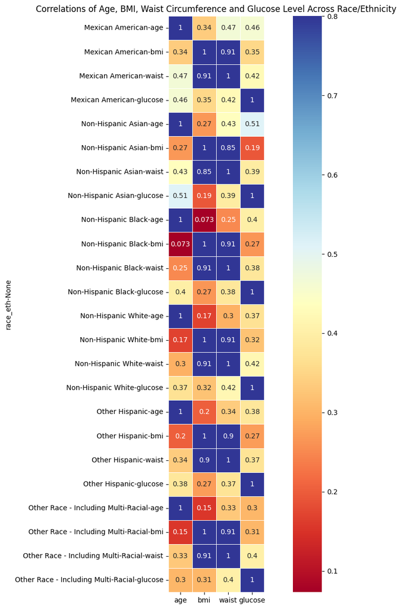

```python
nhanes_raceeth_grouped = nhanes.groupby('race_eth')

# selecting for columns we want to examine
nhanes_corr = nhanes_raceeth_grouped[corrcols]

# Creates a correlation matrix
corrmat = nhanes_corr.corr(method = 'spearman')
corrmat

# Heatmap of correlation matrix
f, ax = plt.subplots(figsize = (15,15))
sns.heatmap(corrmat, vmax = .8, square = True, annot = True, cmap = 'RdYlBu', linewidths = .5 )
plt.title('Correlations of Age, BMI, Waist Circumference and Glucose Level Across Race/Ethnicity')
plt.show()
```

In the general population, we see across all racial/ethnic backgrounds, waist circumference exhibits a stronger correlation with fasting glucose level than BMI. Among respondents identifying as 'Non-Hispanic Asian', this difference in correlation strength is greatest, with waist circumference having a correlation with glucose .2 greater than BMI. This trend validates that in the general population, waist circumference correlates closer with glucose levels than BMI.

### Race/Ethnicity: At Risk Population

| race_eth |  | age | bmi | waist | glucose |
| --- | --- | --- | --- | --- | --- |
| Mexican American | age | 1.000000 | 0.086874 | 0.259019 | 0.353421 |
|  | bmi | 0.086874 | 1.000000 | 0.875375 | 0.083153 |
|  | waist | 0.259019 | 0.875375 | 1.000000 | 0.183767 |
|  | glucose | 0.353421 | 0.083153 | 0.183767 | 1.000000 |
| Non-Hispanic Asian | age | 1.000000 | 0.151100 | 0.310022 | 0.289603 |
|  | bmi | 0.151100 | 1.000000 | 0.795004 | 0.165013 |
|  | waist | 0.310022 | 0.795004 | 1.000000 | 0.406899 |
|  | glucose | 0.289603 | 0.165013 | 0.406899 | 1.000000 |
| Non-Hispanic Black | age | 1.000000 | -0.189737 | -0.031394 | 0.155572 |
|  | bmi | -0.189737 | 1.000000 | 0.902141 | 0.173274 |
|  | waist | -0.031394 | 0.902141 | 1.000000 | 0.202574 |
|  | glucose | 0.155572 | 0.173274 | 0.202574 | 1.000000 |
| Non-Hispanic White | age | 1.000000 | -0.042938 | 0.081241 | 0.268623 |
|  | bmi | -0.042938 | 1.000000 | 0.899795 | 0.156629 |
|  | waist | 0.081241 | 0.899795 | 1.000000 | 0.222493 |
|  | glucose | 0.268623 | 0.156629 | 0.222493 | 1.000000 |
| Other Hispanic | age | 1.000000 | 0.035463 | 0.195221 | 0.343882 |
|  | bmi | 0.035463 | 1.000000 | 0.885546 | 0.239914 |
|  | waist | 0.195221 | 0.885546 | 1.000000 | 0.250068 |
|  | glucose | 0.343882 | 0.239914 | 0.250068 | 1.000000 |
| Other Race - Including Multi-Racial | age | 1.000000 | 0.026248 | 0.177220 | 0.070930 |
|  | bmi | 0.026248 | 1.000000 | 0.911998 | 0.378568 |
|  | waist | 0.177220 | 0.911998 | 1.000000 | 0.381291 |
|  | glucose | 0.070930 | 0.378568 | 0.381291 | 1.000000 |

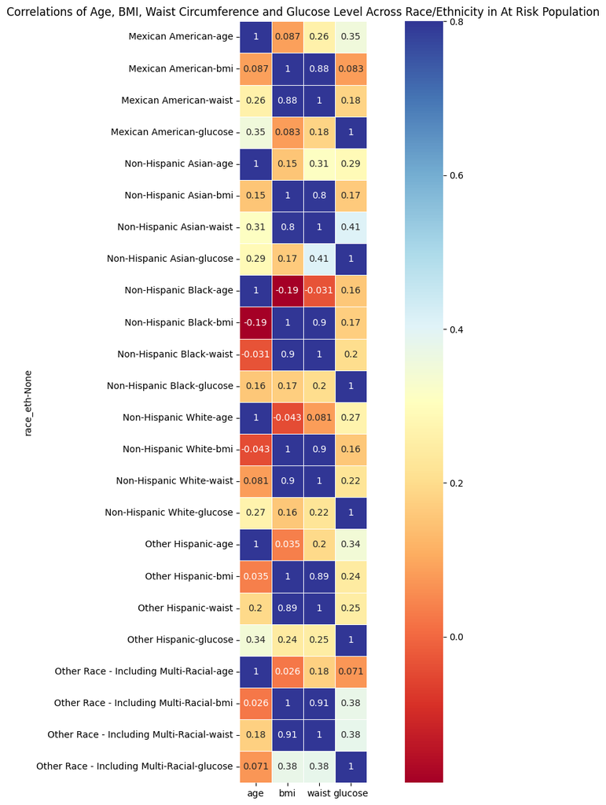

```python
nhanes_atrisk_raceeth_grouped = nhanes_atrisk.groupby('race_eth')

# selecting for columns we want to examine
nhanes_atrisk_corr = nhanes_atrisk_raceeth_grouped[corrcols]

# Creates a correlation matrix
corrmat = nhanes_atrisk_corr.corr(method = 'spearman')
corrmat

# Heatmap of correlation matrix
f, ax = plt.subplots(figsize = (15,15))
sns.heatmap(corrmat, vmax = .8, square = True, annot = True, cmap = 'RdYlBu', linewidths = .5 )
plt.title('Correlations of Age, BMI, Waist Circumference and Glucose Level Across Race/Ethnicity in At Risk Population')
plt.show()
```

In the at risk NHANES population, waist circumference generally sees greater positive correlation with fasting glucose than that of BMI across most racial/ethnic backgrounds. This difference in correlation strength varies by respondent racial/ethnic background in the at risk population, with Non-Hispanic Asian respondents exhibiting the biggest difference in correlation strength between waist circumference and fasting glucose (.41) and BMI and fasting glucose (.17). The smallest difference in correlation strength is seen in respondents identifying as 'Other Race - Including Multi-Racial', where the difference between waist circumference to glucose correlation and BMI to glucose correlation is 0. This trend varies across other respondent racial/ethnic backgrounds, but generally sees that waist circumference exhibits greater positive correlation with glucose levels than BMI.

### Race/Ethnicity: Undiagnosed Population

| race_eth |  | age | bmi | waist | glucose |
| --- | --- | --- | --- | --- | --- |
| Mexican American | age | 1.000000 | -0.024692 | -0.017637 | 0.066430 |
|  | bmi | -0.024692 | 1.000000 | 0.713287 | -0.533892 |
|  | waist | -0.017637 | 0.713287 | 1.000000 | -0.519655 |
|  | glucose | 0.066430 | -0.533892 | -0.519655 | 1.000000 |
| Non-Hispanic Asian | age | 1.000000 | 0.300000 | -0.300000 | 0.052705 |
|  | bmi | 0.300000 | 1.000000 | 0.500000 | 0.158114 |
|  | waist | -0.300000 | 0.500000 | 1.000000 | 0.105409 |
|  | glucose | 0.052705 | 0.158114 | 0.105409 | 1.000000 |
| Non-Hispanic Black | age | 1.000000 | -0.683373 | -0.546698 | -0.313502 |
|  | bmi | -0.683373 | 1.000000 | 0.818182 | -0.050229 |
|  | waist | -0.546698 | 0.818182 | 1.000000 | -0.118723 |
|  | glucose | -0.313502 | -0.050229 | -0.118723 | 1.000000 |
| Non-Hispanic White | age | 1.000000 | -0.168602 | -0.118165 | -0.056273 |
|  | bmi | -0.168602 | 1.000000 | 0.824496 | 0.127483 |
|  | waist | -0.118165 | 0.824496 | 1.000000 | 0.380449 |
|  | glucose | -0.056273 | 0.127483 | 0.380449 | 1.000000 |
| Other Hispanic | age | 1.000000 | -0.324204 | 0.041096 | -0.130435 |
|  | bmi | -0.324204 | 1.000000 | 0.818182 | 0.341687 |
|  | waist | 0.041096 | 0.818182 | 1.000000 | 0.154898 |
|  | glucose | -0.130435 | 0.341687 | 0.154898 | 1.000000 |
| Other Race - Including Multi-Racial | age | 1.000000 | -0.800000 | -0.800000 | -0.200000 |
|  | bmi | -0.800000 | 1.000000 | 1.000000 | -0.400000 |
|  | waist | -0.800000 | 1.000000 | 1.000000 | -0.400000 |
|  | glucose | -0.200000 | -0.400000 | -0.400000 | 1.000000 |

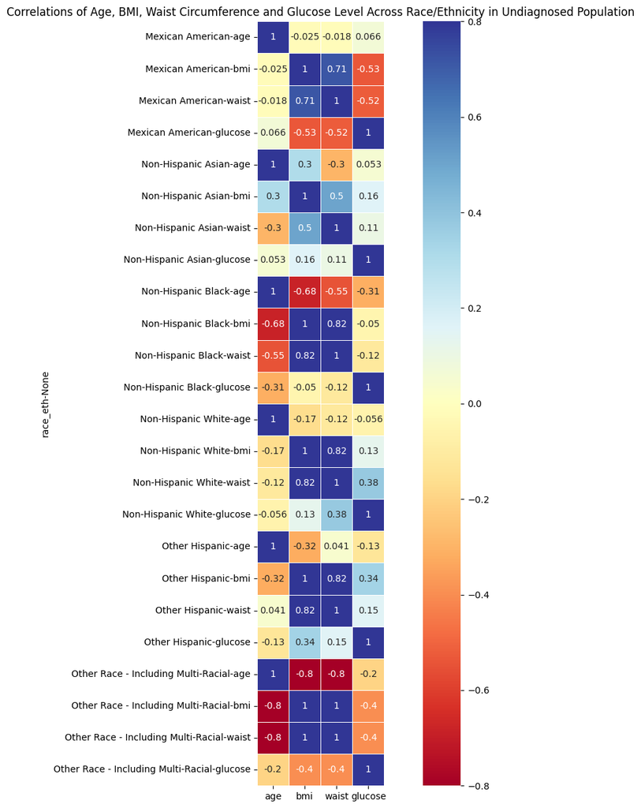

```python
nhanes_undiagnosed_raceeth_grouped = nhanes_undiagnosed.groupby('race_eth')

# selecting for columns we want to examine
nhanes_undiagnosed_corr = nhanes_undiagnosed_raceeth_grouped[corrcols]

# Creates a correlation matrix
corrmat = nhanes_undiagnosed_corr.corr(method = 'spearman')
corrmat

# Heatmap of correlation matrix
f, ax = plt.subplots(figsize = (15,15))
sns.heatmap(corrmat, vmax = .8, square = True, annot = True, cmap = 'RdYlBu', linewidths = .5 )
plt.title('Correlations of Age, BMI, Waist Circumference and Glucose Level Across Race/Ethnicity in Undiagnosed Population')
plt.show()
```

### Aim 3A: General Conclusions

Overall, among general, at risk, and populations, waist circumference exhibits higher positive correlations with fasting glucose levels than that of BMI for both male and female respondents.

Overall, among general and at risk populations, waist circumference exhibits higher positive correlations with fasting glucose levels than that of BMI across racial/ethnic backgrounds. This trend does not apply to undiagnosed patient populations, which see substantial variation in correlation with waist circumference and fasting glucose and BMI and fasting glucose.

## Macronutrient Assessment

Purpose of this section

- Select for respondents that completed nutrient analysis and quesitonnaires
- Determine skewedness for relevant metrics for macronutrient assessment
- Build correlation matrices for general, at risk and undiagnosed populations to determine correlation between macronutrient levels and fasting glucose levels

```python
## Selecting for those that completed the nutrient response section of NHANES
nhanes_nutrients = nhanes[nhanes['recall_status'] == 'Reliable and met the minimum criteria']
nhanes_atrisk_nutrients = nhanes_atrisk[nhanes_atrisk['recall_status'] == 'Reliable and met the minimum criteria']
nhanes_undiagnosed_nutrients = nhanes_undiagnosed[nhanes_undiagnosed['recall_status'] == 'Reliable and met the minimum criteria']

nhanes_nutrients.info()
nhanes_atrisk_nutrients.info()
nhanes_undiagnosed_nutrients.info()
```

```
<class 'pandas.core.frame.DataFrame'>
Index: 2795 entries, 0 to 3497
Data columns (total 20 columns):
 #   Column          Non-Null Count  Dtype
---  ------          --------------  -----
 0   Unnamed: 0      2795 non-null   int64
 1   seqn            2795 non-null   float64
 2   gender          2795 non-null   object
 3   age             2795 non-null   float64
 4   income_status   2795 non-null   float64
 5   race_eth        2795 non-null   object
 6   recall_status   2795 non-null   object
 7   total_calories  2795 non-null   float64
 8   total_protein   2795 non-null   float64
 9   total_carbs     2795 non-null   float64
```

[output cut: 66 more lines]

### Nutrients and General Population:

```python
# nhanes nutrients skew check
nhanes_nutrients.skew(numeric_only = True)

# glucose is positively skewed
glucoseLog = np.log(nhanes_nutrients['glucose'])
glucoseLog.skew()
    # log reduces its skew
```

```
Unnamed: 0         0.021703
seqn               0.011997
age               -0.407229
income_status     -0.135465
total_calories     1.576063
total_protein      1.892809
total_carbs        1.943751
total_sugars       2.845679
total_fiber        1.965823
ratio_protein     24.369276
ratio_sugars      15.016363
ratio_carbs       11.170304
ratio_fiber       29.666416
bmi                1.049463
waist              0.466674
glucose            4.476583
dtype: float64
```

```
2.519216679057294
```

|  | total_calories | total_protein | total_carbs | total_sugars | total_fiber | glucose |
| --- | --- | --- | --- | --- | --- | --- |
| total_calories | 1.000000 | 0.772632 | 0.846551 | 0.625922 | 0.560199 | 0.005464 |
| total_protein | 0.772632 | 1.000000 | 0.514164 | 0.311146 | 0.475191 | 0.019372 |
| total_carbs | 0.846551 | 0.514164 | 1.000000 | 0.810056 | 0.588863 | -0.035927 |
| total_sugars | 0.625922 | 0.311146 | 0.810056 | 1.000000 | 0.344045 | -0.028833 |
| total_fiber | 0.560199 | 0.475191 | 0.588863 | 0.344045 | 1.000000 | -0.022151 |
| glucose | 0.005464 | 0.019372 | -0.035927 | -0.028833 | -0.022151 | 1.000000 |

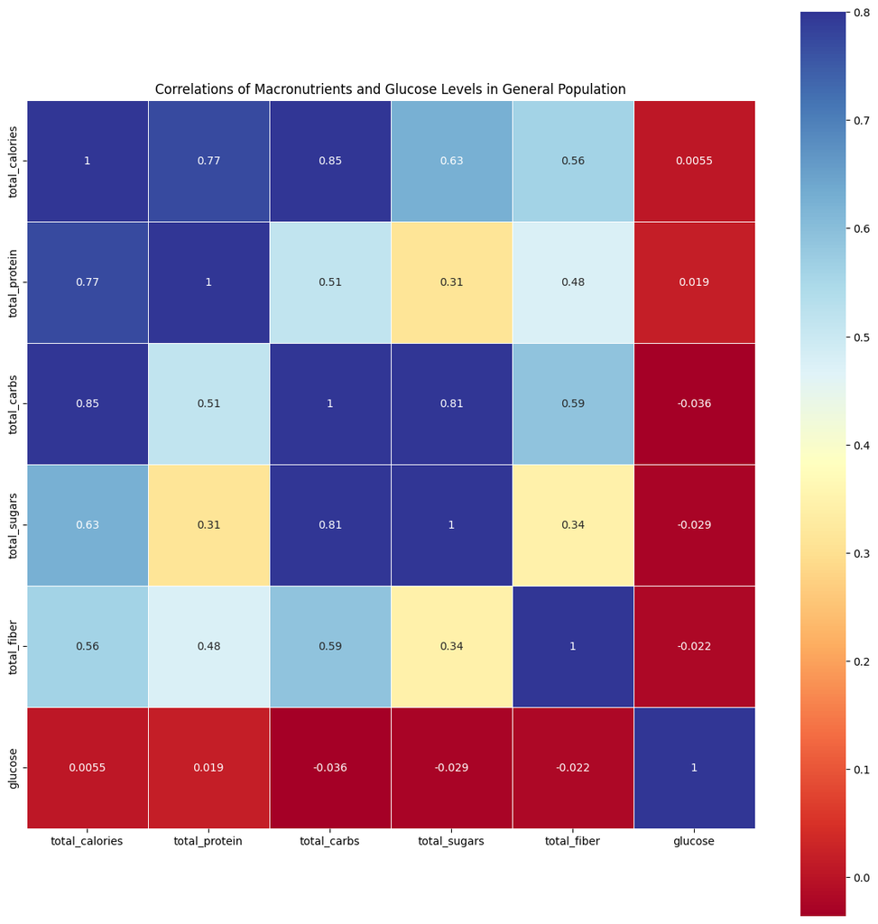

```python
# selecting for columns we want to examine
nutrientcorrcols = ['total_calories', 'total_protein', 'total_carbs', 'total_sugars', 'total_fiber', 'glucose']

nutrients_general_corr = nhanes_nutrients[nutrientcorrcols]

# Creates a correlation matrix
corrmat = nutrients_general_corr.corr(method = 'spearman')
corrmat

# Heatmap of correlation matrix
f, ax = plt.subplots(figsize = (15,15))
sns.heatmap(corrmat, vmax = .8, square = True, annot = True, cmap = 'RdYlBu', linewidths = .5 )
plt.title('Correlations of Macronutrients and Glucose Levels in General Population')
plt.show()
```

Across all total macronutrients, the correlations with glucose levels for the general NHANES population are very weak (all less than .04 in magnitude). This indicates that for the general population, macronutrient intake is not a good assessor of potential glucose level.